# DS6373 Final Project

Daily Deaths and Positivity Rate appear to have some subtle differnces in their distribution for weekday vs weekend. However we must keep in mind we have unbalanced levels overall between the total observations for weekends vs weekdays.

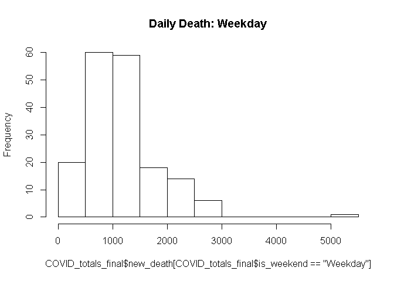

```r
# Daily Death
hist(
  COVID_totals_final$new_death[COVID_totals_final$is_weekend ==  "Weekday"],
  main = "Daily Death: Weekday")
```

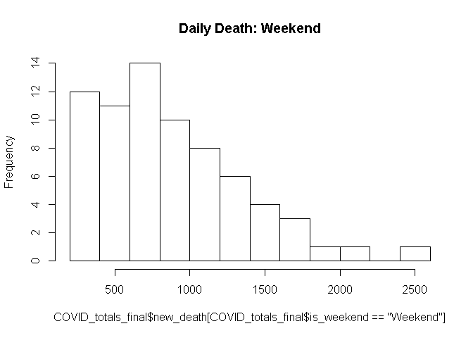

```r
hist(
  COVID_totals_final$new_death[COVID_totals_final$is_weekend ==  "Weekend"],
  main = "Daily Death: Weekend")
```

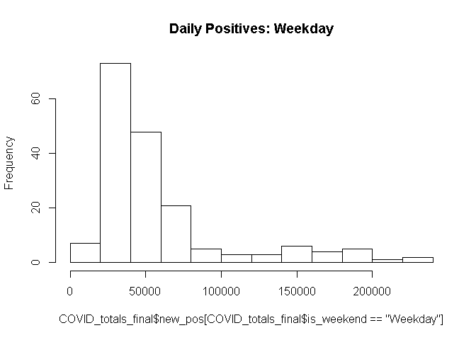

```r
# Daily Positives
hist(
  COVID_totals_final$new_pos[COVID_totals_final$is_weekend ==  "Weekday"],
  main = "Daily Positives: Weekday")
```

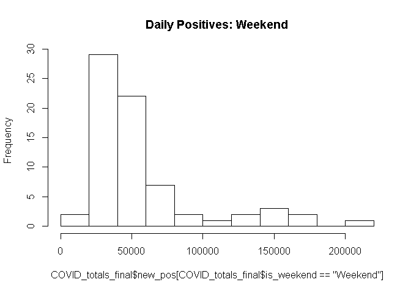

```r
hist(
  COVID_totals_final$new_pos[COVID_totals_final$is_weekend ==  "Weekend"],
  main = "Daily Positives: Weekend")
```

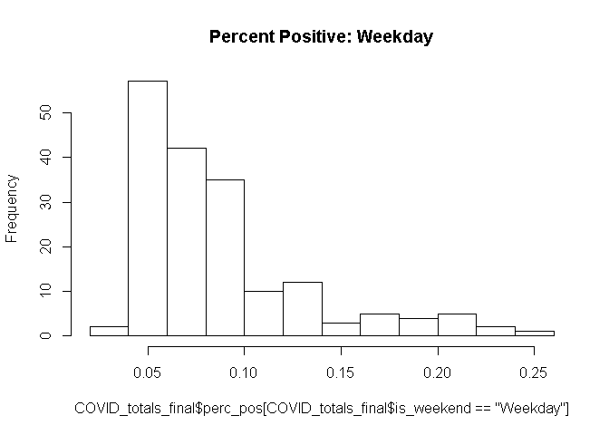

```r
# Positivity
hist(
  COVID_totals_final$perc_pos[COVID_totals_final$is_weekend ==  "Weekday"],
  main = "Percent Positive: Weekday")
```

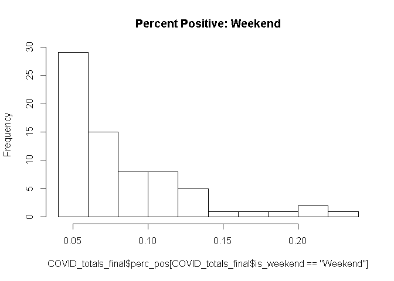

```r
hist(
  COVID_totals_final$perc_pos[COVID_totals_final$is_weekend ==  "Weekend"],
  main = "Percent Positive: Weekend")
```

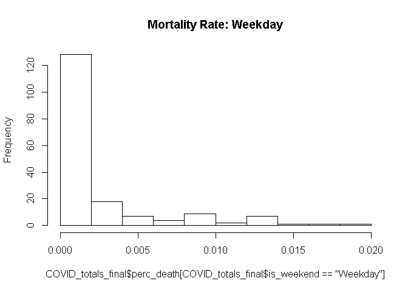

```r
# Mortality
hist(
  COVID_totals_final$perc_death[COVID_totals_final$is_weekend ==  "Weekday"],
  main = "Mortality Rate: Weekday")
```

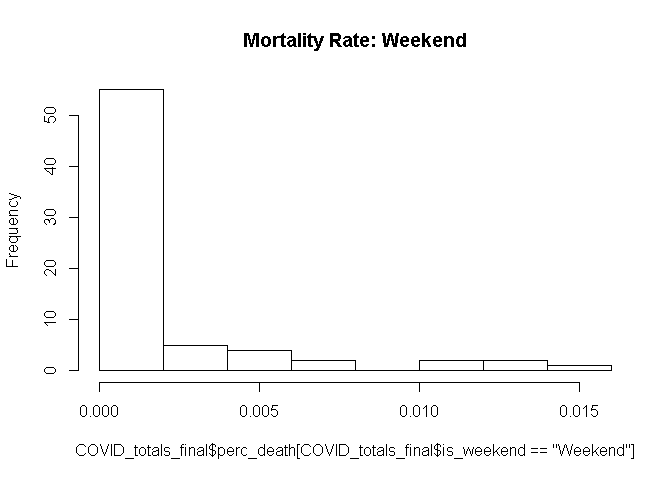

```r
hist(
  COVID_totals_final$perc_death[COVID_totals_final$is_weekend ==  "Weekend"],
  main = "Mortality Rate: Weekend")
```

### Hospitalization - Lagged Correlation

Unfortunately we only find weakly moderate correlations

```r
cor.test( COVID_totals_final$new_death , COVID_totals_final$hospital_sum )
```

```
##
##  Pearson's product-moment correlation
##
## data:  COVID_totals_final$new_death and COVID_totals_final$hospital_sum
## t = 9.5143, df = 247, p-value < 2.2e-16
## alternative hypothesis: true correlation is not equal to 0
## 95 percent confidence interval:
##  0.4206425 0.6033498
## sample estimates:
##       cor
## 0.5178776
```

```r
cor.test( COVID_totals_final$perc_death , COVID_totals_final$hospital_sum )
```

```
##
##  Pearson's product-moment correlation
##
## data:  COVID_totals_final$perc_death and COVID_totals_final$hospital_sum
## t = 5.1144, df = 247, p-value = 6.317e-07
## alternative hypothesis: true correlation is not equal to 0
## 95 percent confidence interval:
##  0.1925395 0.4176966
## sample estimates:
##       cor
## 0.3094489
```

```r
# does hospitalization correlate to daily positives
# can it stop people from dying

ccf(COVID_totals_final$new_pos, COVID_totals_final$hospital_sum, lag.max = 14, type = "correlation", plot = F )
```

```
##
## Autocorrelations of series 'X', by lag
##
##   -14   -13   -12   -11   -10    -9    -8    -7    -6    -5    -4    -3
## 0.473 0.482 0.486 0.496 0.507 0.502 0.517 0.519 0.517 0.511 0.513 0.521
##    -2    -1     0     1     2     3     4     5     6     7     8     9
## 0.532 0.552 0.568 0.564 0.530 0.494 0.457 0.421 0.390 0.361 0.330 0.298
##    10    11    12    13    14
## 0.263 0.227 0.194 0.164 0.135
```

```r
ccf(COVID_totals_final$new_death, COVID_totals_final$hospital_sum, lag.max = 14, type = "correlation", plot = F )
```

```
##
## Autocorrelations of series 'X', by lag
##
##   -14   -13   -12   -11   -10    -9    -8    -7    -6    -5    -4    -3
## 0.309 0.314 0.309 0.334 0.365 0.380 0.402 0.411 0.404 0.386 0.400 0.426
##    -2    -1     0     1     2     3     4     5     6     7     8     9
## 0.457 0.491 0.518 0.544 0.522 0.501 0.484 0.475 0.471 0.470 0.455 0.432
##    10    11    12    13    14
## 0.412 0.394 0.384 0.377 0.373
```

```r
ccf(COVID_totals_final$perc_death, COVID_totals_final$hospital_sum, lag.max = 14, type = "correlation", plot = F )
```

```
##
## Autocorrelations of series 'X', by lag
##
##   -14   -13   -12   -11   -10    -9    -8    -7    -6    -5    -4    -3
## 0.288 0.298 0.307 0.317 0.331 0.344 0.352 0.357 0.354 0.346 0.340 0.335
##    -2    -1     0     1     2     3     4     5     6     7     8     9
## 0.332 0.324 0.309 0.294 0.283 0.274 0.259 0.252 0.242 0.236 0.226 0.211
##    10    11    12    13    14
## 0.202 0.196 0.190 0.184 0.186
```

```r
ccf(COVID_totals_final$perc_pos, COVID_totals_final$new_death, lag.max = 14, type = "correlation", plot = F  )
```

```
##
## Autocorrelations of series 'X', by lag
##
##   -14   -13   -12   -11   -10    -9    -8    -7    -6    -5    -4    -3
## 0.621 0.617 0.595 0.566 0.567 0.585 0.611 0.641 0.644 0.600 0.562 0.548
##    -2    -1     0     1     2     3     4     5     6     7     8     9
## 0.546 0.563 0.641 0.644 0.573 0.456 0.463 0.423 0.418 0.442 0.416 0.373
##    10    11    12    13    14
## 0.320 0.280 0.247 0.244 0.280
```

```r
#plot(COVID_totals_final$new_pos, (COVID_totals_final$new_death + COVID_totals_final$hospital_sum ) )
#plot(COVID_totals_final$perc_pos, COVID_totals_final$new_death)
```

### VAR

Looking for lagged correlation between hospitalized patients in order to help understand if hospitalization is effectively identifying or controlling COVID outbreaks, or if fatalities from the past are an indication on infection in the future.

```r
#new_pos.mtx <- cbind( COVID_totals_final$new_pos, COVID_totals_final$hospital_sum  )
new_pos.mtx <- cbind(
  COVID_totals_final$new_pos,
  #COVID_totals_final$perc_pos,
  COVID_totals_final$hospital_sum,
  COVID_totals_final$new_death
  )


# picks p of 10
VARselect(new_pos.mtx, lag.max = 22, type = "both" )$selection
```

```
## AIC(n)  HQ(n)  SC(n) FPE(n)
##     14      7      7     14
```

####Short Term VAR Forecast

AIC identifies p of 14 BIC identifies p of 7

```r
# VAR model
VAR(new_pos.mtx, p=7, type = "both") -> new_pos.var
# predictions
predict(new_pos.var, n.ahead = 7 ) -> new_pos.var.pred7
```

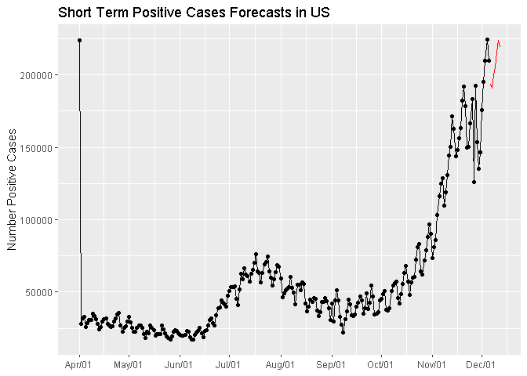

```r
dates <- seq(as.Date(COVID_totals_final$date[ length(COVID_totals_final$date) ]), by='day', length.out=8)[c(-1)]

forecasts <- data.frame(
  preds = new_pos.var.pred7$fcst$y1[,1],
  upper = new_pos.var.pred7$fcst$y1[,3],
  lower = new_pos.var.pred7$fcst$y1[,2],
  dates = dates
  )

#Visualize
ggplot(data=COVID_totals_final, aes(x=date, y=new_pos)) +
  geom_line()+geom_point() + ggtitle('Short Term Positive Cases Forecasts in US')+
  xlab(NULL)+ylab('Number Positive Cases')+
  scale_x_date(date_labels = "%b/%d", date_breaks = '1 month')+
  #scale_y_continuous(breaks=seq(0,3000, 300))+
  geom_line(data=forecasts, aes(x=dates, y=preds), color='red')
```

####VAR ASE

```r
#test / train split

new_pos.mtx[ 1:(length(new_pos.mtx[,1]) - 20),  ] -> new_pos.mtx.train
new_pos.mtx[ (length(new_pos.mtx[,1]) - 19) : length(new_pos.mtx[,1]) ,] -> new_pos.mtx.test



# VAR model
VAR(new_pos.mtx.train, p=7, type = "trend") -> new_pos.var.train
# predictions
predict(new_pos.var.train, n.ahead = 20 ) -> new_pos.var.ase


mean((new_pos.var.ase$fcst$y1[,1] - new_pos.mtx.test[,1])^2)
```

```
## [1] 1579024646
```

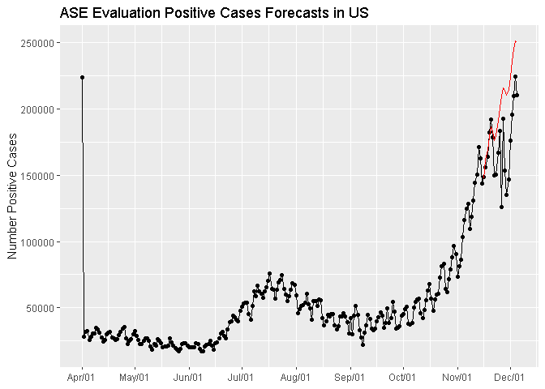

```r
dates <- seq(as.Date(COVID_totals_final$date[ length(COVID_totals_final$date)-20 ]), by='day', length.out=21)[c(-1)]

forecasts <- data.frame(
  preds = new_pos.var.ase$fcst$y1[,1],
  upper = new_pos.var.ase$fcst$y1[,3],
  lower = new_pos.var.ase$fcst$y1[,2],
  dates = dates
  )

#Visualize
ggplot(data=COVID_totals_final, aes(x=date, y=new_pos)) +
  geom_line()+geom_point() + ggtitle('ASE Evaluation Positive Cases Forecasts in US')+
  xlab(NULL)+ylab('Number Positive Cases')+
  scale_x_date(date_labels = "%b/%d", date_breaks = '1 month')+
  #scale_y_continuous(breaks=seq(0,3000, 300))+
  geom_line(data=forecasts, aes(x=dates, y=preds), color='red')
```

####Long Term VAR Forecast

```r
# test / train split

# VAR model
VAR(new_pos.mtx, p=7, type = "trend") -> new_pos.var
# predictions
predict(new_pos.var, n.ahead = 90 ) -> new_pos.var.pred90
```

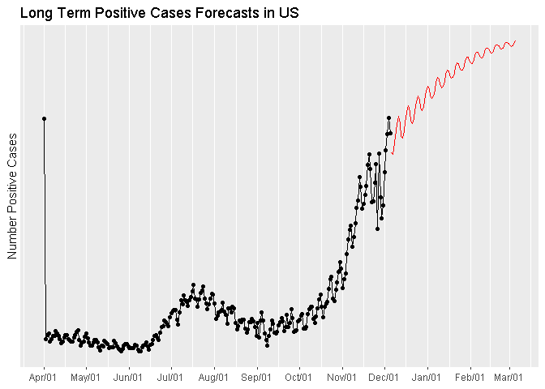

```r
dates <- seq(as.Date(COVID_totals_final$date[ length(COVID_totals_final$date) ]), by='day', length.out=91)[c(-1)]

forecasts <- data.frame(
  preds = new_pos.var.pred90$fcst$y1[,1],
  upper = new_pos.var.pred90$fcst$y1[,3],
  lower = new_pos.var.pred90$fcst$y1[,2],
  dates = dates
  )

#Visualize
ggplot(data=COVID_totals_final, aes(x=date, y=new_pos)) +
  geom_line()+geom_point() + ggtitle('Long Term Positive Cases Forecasts in US')+
  xlab(NULL)+ylab('Number Positive Cases')+
  scale_x_date(date_labels = "%b/%d", date_breaks = '1 month')+
  scale_y_continuous(breaks=seq(0,3000, 300))+
  geom_line(data=forecasts, aes(x=dates, y=preds), color='red')
```

### MLP Model: Multivariate

####Model Evaluation

NOTE: hospital was detracting from model efficacy. Decided to remove it

```r
mlp_length <- length(COVID_totals_final$new_pos)

# TRAIN / TEST SPLIT
# hold out 20
COVID_totals_final$new_pos[1:(mlp_length-20)] %>%
  as.ts() -> new_pos.train


COVID_totals_final$new_pos[(mlp_length-19):mlp_length] %>%
  as.ts() -> new_pos.test

## EXPLANATORY DATAFRAME

xreg.df = data.frame(
  day_of_week = ts(COVID_totals_final$day_of_week) ,
  #hospital_sum = ts(COVID_totals_final$hospital_sum),
  #is_weekend = ts(COVID_totals_final$is_weekend),
  t = as.ts(COVID_totals_final$date - min(COVID_totals_final$date) + 1 )
  )

head(xreg.df)
```

```
##   day_of_week t
## 1           7 1
## 2           5 2
## 3           1 3
## 4           3 4
## 5           4 5
## 6           2 6
```

MLP MODEL STATS

```r
new_pos.mul.mlp <- mlp(
  new_pos.train,
  xreg = xreg.df,
  #difforder = c(1),
  #allow.det.season = F,
  reps = 50,
  comb = "mean")

new_pos.mul.mlp
```

```
## MLP fit with 5 hidden nodes and 50 repetitions.
## Univariate lags: (1,3)
## 1 regressor included.
## - Regressor 1 lags: (1,2,4)
## Forecast combined using the mean operator.
## MSE: 13969673.4034.
```

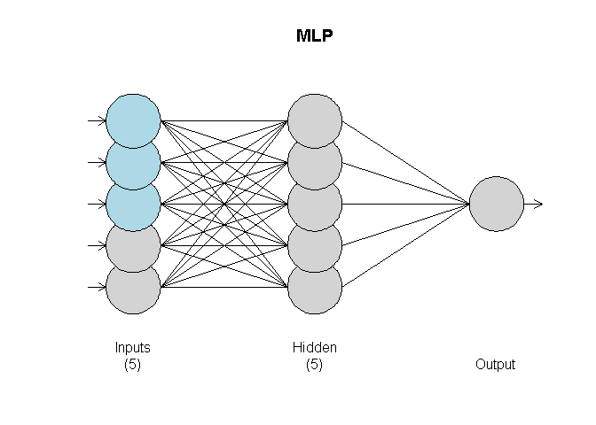

```r
# Visualize the Neural Network
plot(new_pos.mul.mlp)
```

We forecast out the 20 hold out values and visually examine them. First in context of the entire realization…

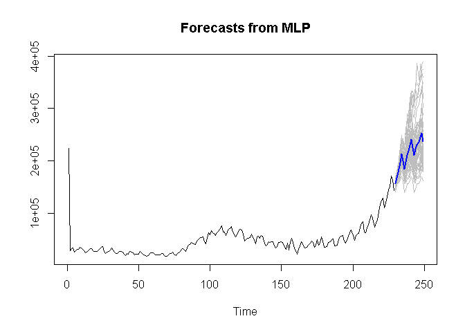

```r
#MLP Forecast
new_pos.mul.mlp.f <- forecast(new_pos.mul.mlp, h = 20, xreg = xreg.df )
plot(new_pos.mul.mlp.f)
```

Then focusing on comparing the last 20 with both the actual in black vs the projected in red.

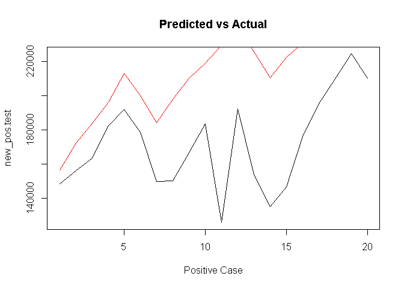

```r
plot(new_pos.test,type = "l", main = "Predicted vs Actual", xlab = "Positive Case" )
lines(seq(1,20),new_pos.mul.mlp.f$mean, col = "red")
```

```r
#ASE
mean(( new_pos.test - as.numeric(new_pos.mul.mlp.f$mean) )^2)
```

```
## [1] 2277468207
```

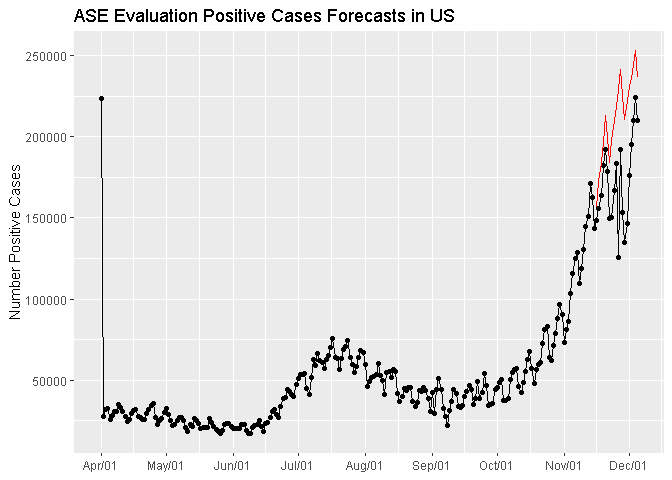

```r
dates <- seq(as.Date(COVID_totals_final$date[ length(COVID_totals_final$date)-20 ]), by='day', length.out=21)[c(-1)]

forecasts <- data.frame(
  preds = new_pos.mul.mlp.f$mean,
  dates = dates
  )

#Visualize
ggplot(data=COVID_totals_final, aes(x=date, y=new_pos)) +
  geom_line()+geom_point() + ggtitle('ASE Evaluation Positive Cases Forecasts in US')+
  xlab(NULL)+ylab('Number Positive Cases')+
  scale_x_date(date_labels = "%b/%d", date_breaks = '1 month')+
  #scale_y_continuous(breaks=seq(0,3000, 300))+
  geom_line(data=forecasts, aes(x=dates, y=preds), color='red')
```

####Short-Term Multivariate MLP Forecast

In order to forecast out we need to prepare the xreg dataframe with 7 day projection of the explanatory variables:

```r
#next 7 is_weekends
last_day = COVID_totals_final$date[ length(COVID_totals_final$date) ]
next7dates = seq(last_day, by = "day", length.out = 8)[-1]
next7weekdays = as.factor(weekdays(next7dates))
next7_isweekend = ifelse(next7weekdays %in% c("Saturday","Sunday"), 'Weekend', 'Weekday')
next7_isweekend = as.factor(next7_isweekend)

#next 7 days
mlp_length <- length(COVID_totals_final$new_pos)
(mlp_length+1):(mlp_length+7) -> next7time

#t parameter
t <- as.numeric(COVID_totals_final$date - min(COVID_totals_final$date) + 1 )

#combine 7 day forecasts with previous dependent vars
xreg7 <- data.frame(
  #is_weekend = ts(c(COVID_totals_final$is_weekend, next7_isweekend)),
  day_of_week = ts( c(COVID_totals_final$day_of_week , next7weekdays)),
  time = ts(c( t , next7time))
  )
```

Now we forecast

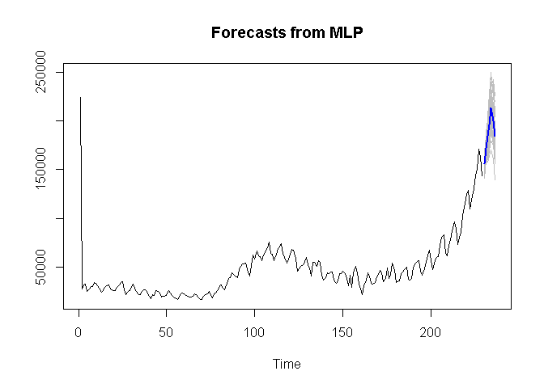

```r
#forecast the next 7 total positive datapoints using the
#forecasted time and is_weekend as predictors
new_pos.mlp.next7 = forecast(new_pos.mul.mlp, h = 7, xreg = xreg7)
plot(new_pos.mlp.next7)
```

####Long-Term Multivariate MLP Forecast

In order to forecast out we need to prepare the xreg dataframe with 90 day projection of the explanatory variables:

```r
#next 7 is_weekends
last_day = COVID_totals_final$date[ length(COVID_totals_final$date) ]
next90dates = seq(last_day, by = "day", length.out = 91)[-1]
next90weekdays = as.factor(weekdays(next90dates))
next90_isweekend = ifelse(next90weekdays %in% c("Saturday","Sunday"), 'Weekend', 'Weekday')
next90_isweekend = as.factor(next90_isweekend)

#next 7 days
mlp_length <- length(COVID_totals_final$new_pos)
(mlp_length+1):(mlp_length+90) -> next90time

#t parameter
t <- as.numeric(COVID_totals_final$date - min(COVID_totals_final$date) + 1 )

#combine 90 day forecasts with previous dependent vars
xreg90 <- data.frame(
  #is_weekend = ts(c(COVID_totals_final$is_weekend, next90_isweekend)),
  day_of_week = ts( c(COVID_totals_final$day_of_week , next90weekdays)),
  time = ts(c( t , next90time))
  )
```

Now we forecast

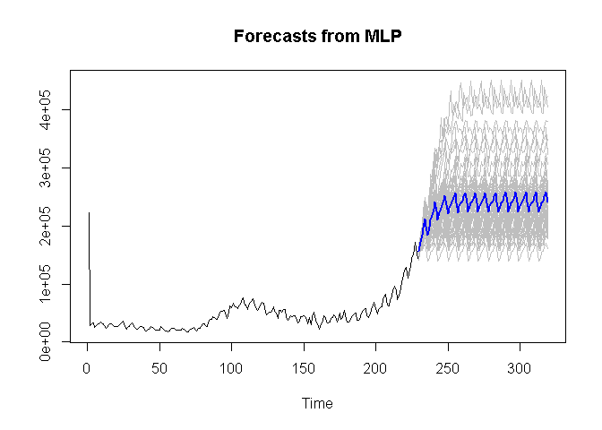

```r
#forecast the next 7 total positive datapoints using the
#forecasted time and is_weekend as predictors
new_pos.mlp.next90 <- forecast(new_pos.mul.mlp, h = 90, xreg = xreg90)
plot(new_pos.mlp.next90)
```

###Short-Term Multivariate Ensemble

We average the predictions from the ARIMA Univariate, Univariate and Multivariate MLP, and VAR Multivariate

**RED** - Ensemble

- ARIMA Univariate
- VAR Multivariate
- MLP Univariate
- MLP Multivariate

**BLUE** - Ensemble exludes MPL Univariate

- ARIMA Univariate
- VAR Multivariate
- MLP Multivariate

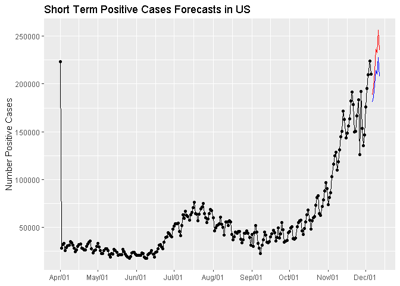

```r
dates <- seq(as.Date(COVID_totals_final$date[ length(COVID_totals_final$date) ]), by='day', length.out=8)[c(-1)]

forecasts <- data.frame(
  preds = (new_pos.fcast7$f + as.vector(new_pos.mlp.f7$mean) + as.vector(new_pos.mlp.next7[[2]]) + new_pos.var.pred7$fcst$y1[,1] )/4,
  predsmult = (new_pos.fcast7$f + as.vector(new_pos.mlp.next7[[2]]) + new_pos.var.pred7$fcst$y1[,1] )/3 ,
  dates = dates
  )

#Visualize
ggplot(data=COVID_totals_final, aes(x=date, y=new_pos)) +
  geom_line()+geom_point() + ggtitle('Short Term Positive Cases Forecasts in US')+
  xlab(NULL)+ylab('Number Positive Cases')+
  scale_x_date(date_labels = "%b/%d", date_breaks = '1 month')+
  #scale_y_continuous(breaks=seq(0,3000, 300))+
  geom_line(data=forecasts, aes(x=dates, y=preds), color='red')+
  geom_line(data=forecasts, aes(x=dates, y=predsmult), color='blue')
```

Comparing predictions of different models

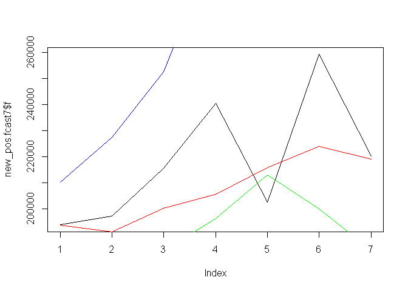

```r
# ARIMA Univariate
plot(new_pos.fcast7$f,type = "l")
# VAR Multivariate
lines(seq(1,7), as.vector(new_pos.var.pred7$fcst$y1[,1]) , col = "red")
# MLP Univariate
lines(seq(1,7), as.vector(new_pos.mlp.f7$mean) , col = "blue")
# MLP Multivariate
lines(seq(1,7), as.vector(new_pos.mlp.next7[[2]]) , col = "green")
```

###Long-Term Multivariate Ensemble

We average the predictions from the ARIMA Univariate, Univariate and Multivariate MLP, and VAR Multivariate

**RED** - Ensemble

- ARIMA Univariate
- VAR Multivariate
- MLP Univariate
- MLP Multivariate

**BLUE** - Ensemble exludes MPL Univariate

- ARIMA Univariate
- VAR Multivariate
- MLP Multivariate

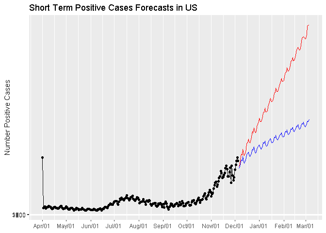

```r
dates <- seq(as.Date(COVID_totals_final$date[ length(COVID_totals_final$date) ]), by='day', length.out=91)[c(-1)]

forecasts <- data.frame(
  preds = (new_pos.fcast90$f + as.vector(new_pos.mlp.f90$mean) + as.vector(new_pos.mlp.next90[[2]]) + new_pos.var.pred90$fcst$y1[,1] )/4,
  predsmult = (new_pos.fcast90$f + as.vector(new_pos.mlp.next90[[2]]) + new_pos.var.pred90$fcst$y1[,1] )/3,
  dates = dates
  )

#Visualize
ggplot(data=COVID_totals_final, aes(x=date, y=new_pos)) +
  geom_line()+geom_point() + ggtitle('Short Term Positive Cases Forecasts in US')+
  xlab(NULL)+ylab('Number Positive Cases')+
  scale_x_date(date_labels = "%b/%d", date_breaks = '1 month')+
  scale_y_continuous(breaks=seq(0,3000, 300))+
  geom_line(data=forecasts, aes(x=dates, y=preds), color='red')+
  geom_line(data=forecasts, aes(x=dates, y=predsmult), color='blue')
```

Comparing predictions of different models

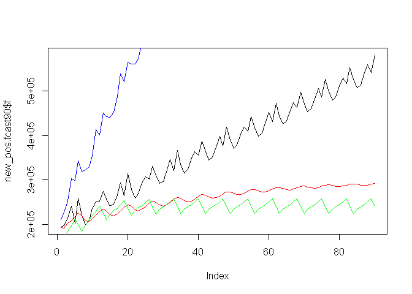

```r
# ARIMA Univariate
plot(new_pos.fcast90$f,type = "l")
# VAR Multivariate
lines(seq(1,90), as.vector(new_pos.var.pred90$fcst$y1[,1]) , col = "red")
# MLP Univariate
lines(seq(1,90), as.vector(new_pos.mlp.f90$mean) , col = "blue")
# MLP Multivariate
lines(seq(1,90), as.vector(new_pos.mlp.next90[[2]]) , col = "green")
```

# CA State: Positive Cases

## California State Data

For later analysis we separate out the data specifically from California

```r
#CALIFORNIA ONLY

#filter for only CA
covidclean_ca.df <- covidclean.df[covidclean.df$state == 'CA',]


#select cols of interest
COVID_totals_final_ca <- covidclean_ca.df[,c("date", "positive","negative", "death", 'hospitalizedCurrently')]

#Reorder sequentially
COVID_totals_final_ca <- COVID_totals_final_ca[ order(COVID_totals_final_ca$date), ]


head(COVID_totals_final_ca)
```

```
##             date positive negative death hospitalizedCurrently
## 12653 2020-04-01     8155    21772   171                  1855
## 12602 2020-04-02     9191    23809   203                  1922
## 12551 2020-04-03    10701    24599   237                  2188
## 12500 2020-04-04    12026   101674   276                  2300
## 12449 2020-04-05    13438   103095   319                  2398
## 12398 2020-04-06    14336   103095   343                  2509
```

```r
# recheck missing values
aggr(COVID_totals_final_ca,
     prop = FALSE,
     combined = TRUE,
     plot = FALSE,
     numbers = TRUE,
     sortVars = TRUE,
     sortCombs = TRUE)
```

```
##
##  Missings in variables:
## [1] Variable Count
## <0 rows> (or 0-length row.names)
```

### Data Cleaning: CA State

We aggregate into a single data frame for easier and more consistent analysis

```r
#Create totals column
COVID_totals_final_ca$MyTotal <- (COVID_totals_final_ca$positive + COVID_totals_final_ca$negative)

#Create new columns for new positives, new negatives, new total, death
new_pos <- c(COVID_totals_final_ca$positive[1], diff(COVID_totals_final_ca$positive, 1))
COVID_totals_final_ca$new_pos <- new_pos
head(COVID_totals_final_ca)
```

```
##             date positive negative death hospitalizedCurrently MyTotal
## 12653 2020-04-01     8155    21772   171                  1855   29927
## 12602 2020-04-02     9191    23809   203                  1922   33000
## 12551 2020-04-03    10701    24599   237                  2188   35300
## 12500 2020-04-04    12026   101674   276                  2300  113700
## 12449 2020-04-05    13438   103095   319                  2398  116533
## 12398 2020-04-06    14336   103095   343                  2509  117431
##       new_pos
## 12653    8155
## 12602    1036
## 12551    1510
## 12500    1325
## 12449    1412
## 12398     898
```

```r
#Create new negative
new_neg <- c(COVID_totals_final_ca$negative[1], diff(COVID_totals_final_ca$negative, 1))
COVID_totals_final_ca$new_neg <- new_neg
head(COVID_totals_final_ca)
```

```
##             date positive negative death hospitalizedCurrently MyTotal
## 12653 2020-04-01     8155    21772   171                  1855   29927
## 12602 2020-04-02     9191    23809   203                  1922   33000
## 12551 2020-04-03    10701    24599   237                  2188   35300
## 12500 2020-04-04    12026   101674   276                  2300  113700
## 12449 2020-04-05    13438   103095   319                  2398  116533
## 12398 2020-04-06    14336   103095   343                  2509  117431
##       new_pos new_neg
## 12653    8155   21772
## 12602    1036    2037
## 12551    1510     790
## 12500    1325   77075
## 12449    1412    1421
## 12398     898       0
```

```r
#Create new total
new_total <- c(COVID_totals_final_ca$MyTotal[1], diff(COVID_totals_final_ca$MyTotal, 1))
COVID_totals_final_ca$new_total <- new_total
head(COVID_totals_final_ca)
```

```
##             date positive negative death hospitalizedCurrently MyTotal
## 12653 2020-04-01     8155    21772   171                  1855   29927
## 12602 2020-04-02     9191    23809   203                  1922   33000
## 12551 2020-04-03    10701    24599   237                  2188   35300
## 12500 2020-04-04    12026   101674   276                  2300  113700
## 12449 2020-04-05    13438   103095   319                  2398  116533
## 12398 2020-04-06    14336   103095   343                  2509  117431
##       new_pos new_neg new_total
## 12653    8155   21772     29927
## 12602    1036    2037      3073
## 12551    1510     790      2300
## 12500    1325   77075     78400
## 12449    1412    1421      2833
## 12398     898       0       898
```

```r
#Create new death
new_death <- c(COVID_totals_final_ca$death[1], diff(COVID_totals_final_ca$death, 1))
COVID_totals_final_ca$new_death = new_death
head(COVID_totals_final_ca)
```

```
##             date positive negative death hospitalizedCurrently MyTotal
## 12653 2020-04-01     8155    21772   171                  1855   29927
## 12602 2020-04-02     9191    23809   203                  1922   33000
## 12551 2020-04-03    10701    24599   237                  2188   35300
## 12500 2020-04-04    12026   101674   276                  2300  113700
## 12449 2020-04-05    13438   103095   319                  2398  116533
## 12398 2020-04-06    14336   103095   343                  2509  117431
##       new_pos new_neg new_total new_death
## 12653    8155   21772     29927       171
## 12602    1036    2037      3073        32
## 12551    1510     790      2300        34
## 12500    1325   77075     78400        39
## 12449    1412    1421      2833        43
## 12398     898       0       898        24
```

```r
#Create percent positive column
COVID_totals_final_ca$perc_pos <- (
  COVID_totals_final_ca$new_pos/COVID_totals_final_ca$new_total
)
head(COVID_totals_final_ca)
```

```
##             date positive negative death hospitalizedCurrently MyTotal
## 12653 2020-04-01     8155    21772   171                  1855   29927
## 12602 2020-04-02     9191    23809   203                  1922   33000
## 12551 2020-04-03    10701    24599   237                  2188   35300
## 12500 2020-04-04    12026   101674   276                  2300  113700
## 12449 2020-04-05    13438   103095   319                  2398  116533
## 12398 2020-04-06    14336   103095   343                  2509  117431
##       new_pos new_neg new_total new_death   perc_pos
## 12653    8155   21772     29927       171 0.27249641
## 12602    1036    2037      3073        32 0.33712984
## 12551    1510     790      2300        34 0.65652174
## 12500    1325   77075     78400        39 0.01690051
## 12449    1412    1421      2833        43 0.49841158
## 12398     898       0       898        24 1.00000000
```

```r
#Create mortality rate column
COVID_totals_final_ca$perc_death <- (
  COVID_totals_final_ca$new_death/COVID_totals_final_ca$new_total
)
head(COVID_totals_final_ca)
```

```
##             date positive negative death hospitalizedCurrently MyTotal
## 12653 2020-04-01     8155    21772   171                  1855   29927
## 12602 2020-04-02     9191    23809   203                  1922   33000
## 12551 2020-04-03    10701    24599   237                  2188   35300
## 12500 2020-04-04    12026   101674   276                  2300  113700
## 12449 2020-04-05    13438   103095   319                  2398  116533
## 12398 2020-04-06    14336   103095   343                  2509  117431
##       new_pos new_neg new_total new_death   perc_pos  perc_death
## 12653    8155   21772     29927       171 0.27249641 0.005713904
## 12602    1036    2037      3073        32 0.33712984 0.010413277
## 12551    1510     790      2300        34 0.65652174 0.014782609
## 12500    1325   77075     78400        39 0.01690051 0.000497449
## 12449    1412    1421      2833        43 0.49841158 0.015178256
## 12398     898       0       898        24 1.00000000 0.026726058
```

```r
#rename 'hospitalizedCurrently' to "hospital_sum" for consistent coding
names(COVID_totals_final_ca)[5] <- "hospital_sum"

#add day_of_week
weekdays(COVID_totals_final_ca$date) %>% as.factor() -> COVID_totals_final_ca$day_of_week

#replace infinity values with 0
#COVID_totals_final_ca[is.infinite(COVID_totals_final_ca$perc_pos), 'perc_pos'] = 0
#COVID_totals_final_ca[is.na(COVID_totals_final_ca$perc_pos), 'perc_pos'] = 0
#sum(is.infinite(COVID_totals_final_ca$perc_pos)) #0


#check for NAN to inf from division by 0
COVID_totals_final_ca[is.na(COVID_totals_final_ca$perc_pos), 'perc_pos']
```

```
## numeric(0)
```

```r
COVID_totals_final_ca[is.na(COVID_totals_final_ca$perc_death), 'perc_death']
```

```
## numeric(0)
```

```r
#Drop columns
COVID_totals_final_ca <- COVID_totals_final_ca %>% dplyr::select( -c('positive', 'negative', 'MyTotal', 'death'))



# verify
str(COVID_totals_final_ca)
```

```
## 'data.frame':    249 obs. of  9 variables:
##  $ date        : Date, format: "2020-04-01" "2020-04-02" ...
##  $ hospital_sum: int  1855 1922 2188 2300 2398 2509 2611 2714 2825 2897 ...
##  $ new_pos     : num  8155 1036 1510 1325 1412 ...
##  $ new_neg     : num  21772 2037 790 77075 1421 ...
##  $ new_total   : num  29927 3073 2300 78400 2833 ...
##  $ new_death   : num  171 32 34 39 43 24 31 68 50 49 ...
##  $ perc_pos    : num  0.2725 0.3371 0.6565 0.0169 0.4984 ...
##  $ perc_death  : num  0.005714 0.010413 0.014783 0.000497 0.015178 ...
##  $ day_of_week : Factor w/ 7 levels "Friday","Monday",..: 7 5 1 3 4 2 6 7 5 1 ...
```

```r
head(COVID_totals_final_ca)
```

```
##             date hospital_sum new_pos new_neg new_total new_death
## 12653 2020-04-01         1855    8155   21772     29927       171
## 12602 2020-04-02         1922    1036    2037      3073        32
## 12551 2020-04-03         2188    1510     790      2300        34
## 12500 2020-04-04         2300    1325   77075     78400        39
## 12449 2020-04-05         2398    1412    1421      2833        43
## 12398 2020-04-06         2509     898       0       898        24
##         perc_pos  perc_death day_of_week
## 12653 0.27249641 0.005713904   Wednesday
## 12602 0.33712984 0.010413277    Thursday
## 12551 0.65652174 0.014782609      Friday
## 12500 0.01690051 0.000497449    Saturday
## 12449 0.49841158 0.015178256      Sunday
## 12398 1.00000000 0.026726058      Monday
```

Quickly validate no more missing values

```r
# Validate no more Missing Values
aggr(COVID_totals_final_ca,
     plot = F,
     prop = F,
     combined = F,
     numbers = T,
     sortVars = T,
     sortCombs = T)
```

```
##
##  Missings in variables:
## [1] Variable Count
## <0 rows> (or 0-length row.names)
```

### Days of the Week Ranking - CA State

```r
COVID_totals_final_ca %>%
  dplyr::select(day_of_week, new_death, new_pos, new_neg) %>%
  group_by(day_of_week) %>%
  summarise(
    totalDeath = sum(new_death),
    totalPos = sum(new_pos),
    totalNeg = sum(new_neg)
  ) %>%
  ungroup() %>%
  mutate( totalTests = totalPos + totalNeg) %>%
  mutate( percPos = totalPos / totalTests ) %>%
  mutate( percDeath = totalDeath / totalTests) %>%
  arrange(desc(totalPos))
```

```
## # A tibble: 7 x 7
##   day_of_week totalDeath totalPos totalNeg totalTests percPos percDeath
##   <fct>            <dbl>    <dbl>    <dbl>      <dbl>   <dbl>     <dbl>
## 1 Saturday          3641   213943  3686102    3900045  0.0549  0.000934
## 2 Wednesday         3813   209929  2909588    3119517  0.0673  0.00122
## 3 Friday            3366   196255  3150958    3347213  0.0586  0.00101
## 4 Sunday            2190   191614  3775212    3966826  0.0483  0.000552
## 5 Thursday          3934   186941  2658974    2845915  0.0657  0.00138
## 6 Tuesday           1903   158165  3558967    3717132  0.0426  0.000512
## 7 Monday             944   154778  3850549    4005327  0.0386  0.000236
```

## Univariate Analysis - CA State: Daily Positive

Looking at the data we can immediately see this data appears to violate stationary requirements: the mean depends on time. Visually there appears to be some seasonality present in the data; however this could be due more to data collection cycles rather than the behavior of the disease.

The data also appears to wander and has slowly damping ACFs, thus we may want to difference the data for analysis

Lastly we have a very large outlier on April 1 which is somewhat suspect. This may be a data entry error, so for the purposes of analysis we will start on April 2, 2020

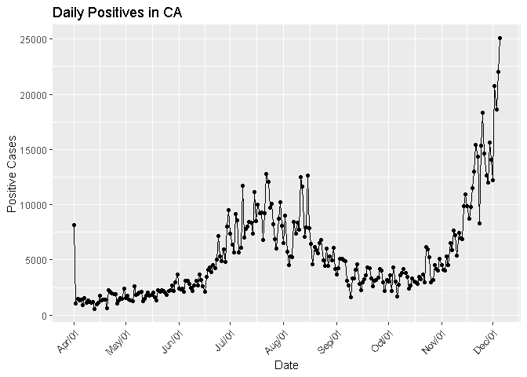

```r
#CA Daily Death
ggplot(data=COVID_totals_final_ca, aes(x=date, y=new_pos)) + geom_point() +
  geom_line() + labs(title='Daily Positives in CA', x='Date', y='Positive Cases')+
  scale_x_date(date_labels = "%b/%d", date_breaks = '1 month')+
  theme(axis.text.x = element_text(angle=45, hjust=1))
```

### Spectrum analysis and ACF plot

Less evidence for seasonality of 7; very small peaks at f = 0.14 and 0.28 which we can test for by overfitting

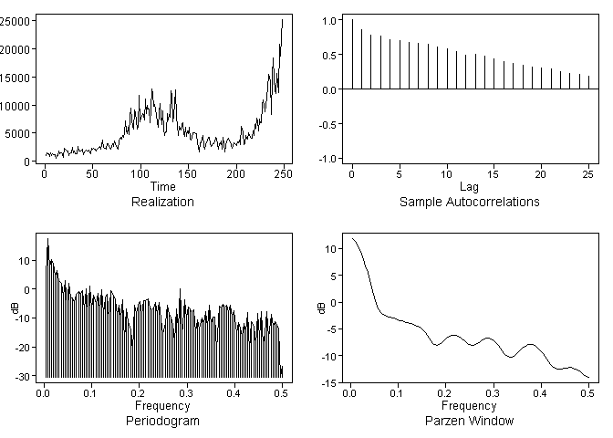

```
## $autplt
##  [1] 1.0000000 0.8648574 0.7839911 0.7644220 0.7219948 0.6986711 0.6713735
##  [8] 0.6598582 0.6469735 0.6071820 0.5874311 0.5436720 0.4946178 0.5080631
## [15] 0.4815786 0.4332978 0.3951530 0.3691541 0.3488564 0.3245715 0.3068785
## [22] 0.2929764 0.2497701 0.2328099 0.2154760 0.1878133
##
## $freq
##   [1] 0.004032258 0.008064516 0.012096774 0.016129032 0.020161290
##   [6] 0.024193548 0.028225806 0.032258065 0.036290323 0.040322581
##  [11] 0.044354839 0.048387097 0.052419355 0.056451613 0.060483871
##  [16] 0.064516129 0.068548387 0.072580645 0.076612903 0.080645161
##  [21] 0.084677419 0.088709677 0.092741935 0.096774194 0.100806452
##  [26] 0.104838710 0.108870968 0.112903226 0.116935484 0.120967742
##  [31] 0.125000000 0.129032258 0.133064516 0.137096774 0.141129032
##  [36] 0.145161290 0.149193548 0.153225806 0.157258065 0.161290323
```

[output cut: 71 more lines]

## ARIMA Model: CA State

###Seasonal Transformation & AR Analysis

Because of the heavy wandering we want to $(1 - B)$ difference the data

We do see weak freq peaks at .28 on the differenced data

```r
# (1 - B) difference
new_pos_ca.d1 <- artrans.wge(new_pos_ca.ts, c(1))
```

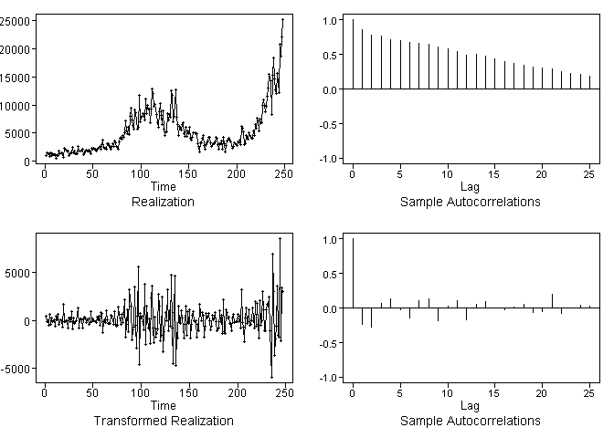

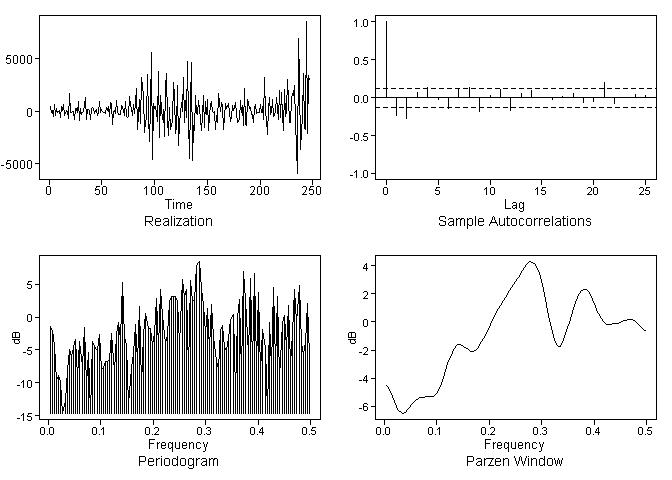

```
## $autplt
##  [1]  1.0000000000 -0.2340627987 -0.2685206653  0.0703529771  0.1318061259
##  [6] -0.0274489734 -0.1453721738  0.1143473458  0.1387073095 -0.1805208790
## [11]  0.0318476315  0.1140447525 -0.1658808033  0.0609813523  0.0990129264
## [16]  0.0066348477 -0.0287070048  0.0130775982  0.0491647952 -0.0640862161
## [21] -0.0567194737  0.2043355502 -0.0705265931  0.0001681953  0.0391991019
## [26]  0.0258442118
##
## $freq
##   [1] 0.004048583 0.008097166 0.012145749 0.016194332 0.020242915
##   [6] 0.024291498 0.028340081 0.032388664 0.036437247 0.040485830
##  [11] 0.044534413 0.048582996 0.052631579 0.056680162 0.060728745
##  [16] 0.064777328 0.068825911 0.072874494 0.076923077 0.080971660
##  [21] 0.085020243 0.089068826 0.093117409 0.097165992 0.101214575
##  [26] 0.105263158 0.109311741 0.113360324 0.117408907 0.121457490
```

[output cut: 73 more lines]

```r
plotts.sample.wge(new_pos_ca.d1 , arlimits = T)
```

**Factor Table**

We overfit with p value of 12 and look at the factor table. When we overfit we see moderate frequencies .14, .28 and .38

Data collection behavior or patients choosing to go or not go in for testing on certain days of the week

```r
#overfit table
est.ar.wge(new_pos_ca.d1 , p=12)
```

```
##
## Coefficients of Original polynomial:
## -0.3560 -0.3802 -0.1767 -0.0280 0.0335 -0.0557 0.0984 0.2028 -0.0143 0.0859 0.0438 -0.2219
##
## Factor                 Roots                Abs Recip    System Freq
## 1+1.3748B+0.8791B^2   -0.7819+-0.7254i      0.9376       0.3810
## 1+0.3854B+0.8761B^2   -0.2200+-1.0455i      0.9360       0.2830
## 1-1.1945B+0.7993B^2    0.7472+-0.8324i      0.8940       0.1336
## 1-0.3577B+0.7839B^2    0.2281+-1.1061i      0.8854       0.2176
## 1+1.6810B+0.7486B^2   -1.1228+-0.2743i      0.8652       0.4619
## 1-1.5330B+0.6142B^2    1.2480+-0.2660i      0.7837       0.0334
##
##
##
## Coefficients of Original polynomial:
## -0.3560 -0.3802 -0.1767 -0.0280 0.0335 -0.0557 0.0984 0.2028 -0.0143 0.0859 0.0438 -0.2219
##
## Factor                 Roots                Abs Recip    System Freq
## 1+1.3748B+0.8791B^2   -0.7819+-0.7254i      0.9376       0.3810
## 1+0.3854B+0.8761B^2   -0.2200+-1.0455i      0.9360       0.2830
## 1-1.1945B+0.7993B^2    0.7472+-0.8324i      0.8940       0.1336
## 1-0.3577B+0.7839B^2    0.2281+-1.1061i      0.8854       0.2176
## 1+1.6810B+0.7486B^2   -1.1228+-0.2743i      0.8652       0.4619
## 1-1.5330B+0.6142B^2    1.2480+-0.2660i      0.7837       0.0334
##
##
```

[output not shown]

[output cut: 53 more lines]

```r
# pick AIC for differenced data

aic5.wge(new_pos_ca.d1, p=0:20, q=0:0) #picks AR(14)
```

```
## ---------WORKING... PLEASE WAIT...
##
##
## Five Smallest Values of  aic
```

```
##       p    q        aic
## 13   12    0   14.61192
## 15   14    0   14.61208
## 17   16    0   14.61296
## 18   17    0   14.61395
## 14   13    0   14.61447
```

```r
aic5.wge(new_pos_ca.d1, p=0:20, q=0:0, type='bic') #picks AR(3)
```

```
## ---------WORKING... PLEASE WAIT...
##
##
## Five Smallest Values of  bic
```

```
##      p    q        bic
## 3    2    0   14.69703
## 4    3    0   14.70397
## 5    4    0   14.72625
## 6    5    0   14.74855
## 7    6    0   14.75582
```

Residuals do appear to be white noise

```r
#white noise test
new_pos_ca.est <- est.ar.wge(new_pos_ca.d1, p=14)
```

```
##
## Coefficients of Original polynomial:
## -0.3510 -0.3692 -0.1875 -0.0372 0.0152 -0.0831 0.0845 0.2071 -0.0059 0.1116 0.1077 -0.1444 0.1237 0.1149
##
## Factor                 Roots                Abs Recip    System Freq
## 1+0.4163B+0.9040B^2   -0.2302+-1.0263i      0.9508       0.2851
## 1+1.3681B+0.8939B^2   -0.7652+-0.7301i      0.9455       0.3787
## 1-0.2949B+0.8306B^2    0.1775+-1.0828i      0.9114       0.2241
## 1-1.0768B+0.7770B^2    0.6929+-0.8982i      0.8815       0.1454
## 1-0.8765B              1.1409               0.8765       0.0000
## 1+1.6364B+0.7178B^2   -1.1399+-0.3063i      0.8472       0.4582
## 1-1.3690B+0.6399B^2    1.0697+-0.6469i      0.7999       0.0866
## 1+0.5474B             -1.8267               0.5474       0.5000
##
##
##
## Coefficients of Original polynomial:
## -0.3510 -0.3692 -0.1875 -0.0372 0.0152 -0.0831 0.0845 0.2071 -0.0059 0.1116 0.1077 -0.1444 0.1237 0.1149
##
## Factor                 Roots                Abs Recip    System Freq
## 1+0.4163B+0.9040B^2   -0.2302+-1.0263i      0.9508       0.2851
## 1+1.3681B+0.8939B^2   -0.7652+-0.7301i      0.9455       0.3787
## 1-0.2949B+0.8306B^2    0.1775+-1.0828i      0.9114       0.2241
## 1-1.0768B+0.7770B^2    0.6929+-0.8982i      0.8815       0.1454
## 1-0.8765B              1.1409               0.8765       0.0000
## 1+1.6364B+0.7178B^2   -1.1399+-0.3063i      0.8472       0.4582
## 1-1.3690B+0.6399B^2    1.0697+-0.6469i      0.7999       0.0866
## 1+0.5474B             -1.8267               0.5474       0.5000
##
##
```

```r
new_pos_ca.ar12 <- artrans.wge(new_pos_ca.d1, new_pos_ca.est$phi)
```

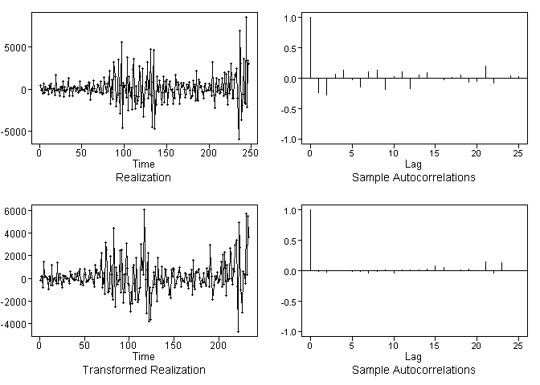

```r
var(new_pos_ca.ar12)
```

```
## [1] 2082014
```

```r
mean(new_pos_ca.ts)
```

```
## [1] 5255.927
```

Validate white noise

In both cases fails to reject H0

```r
ljung.wge(new_pos_ca.ar12)$pval #FTR 0.9847211
```

```
## Obs -0.006265909 -0.01906409 -0.002582277 0.004539837 -0.006406923 -0.01149681 -0.03103254 -0.01273292 0.0131274 -0.03164709 0.01089881 0.0135721 0.01142354 0.02431042 0.07524752 0.05937973 -0.0003787045 0.01894807 0.03542451 0.008455904 0.1503122 -0.03718011 0.128268 0.002643675
```

```
## [1] 0.9422817
```

```r
ljung.wge(new_pos_ca.ar12, K=48)$pval #FTR 0.9970605
```

```
## Obs -0.006265909 -0.01906409 -0.002582277 0.004539837 -0.006406923 -0.01149681 -0.03103254 -0.01273292 0.0131274 -0.03164709 0.01089881 0.0135721 0.01142354 0.02431042 0.07524752 0.05937973 -0.0003787045 0.01894807 0.03542451 0.008455904 0.1503122 -0.03718011 0.128268 0.002643675 0.0006662341 -0.…
```

```
## [1] 0.9877277
```

### ARIMA: Short Term Forecasts

Forecasting out 7 days. As expected with $(1 - B)$ model, cycles around last value

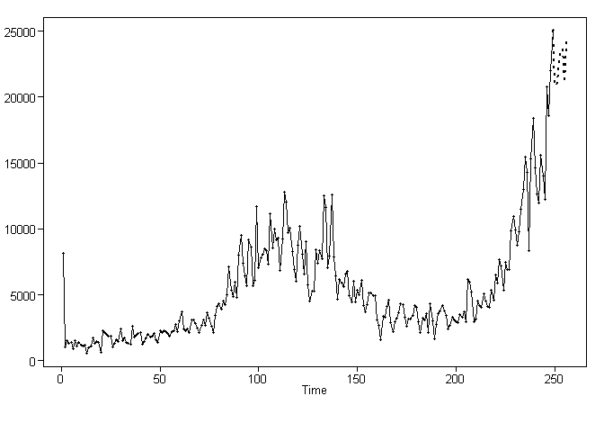

```r
# short-term forecasts of n = 7
fore.aruma.wge(COVID_totals_final_ca$new_pos,
               phi=new_pos_ca.est$phi,
               d=1,
               n.ahead=7,
               limits=F) -> new_pos_ca.fcast7
```

**GGPLOT VISUALIZATION OF FORECASTS**

NOTE: Only doing this for **this one stat** so we have the code

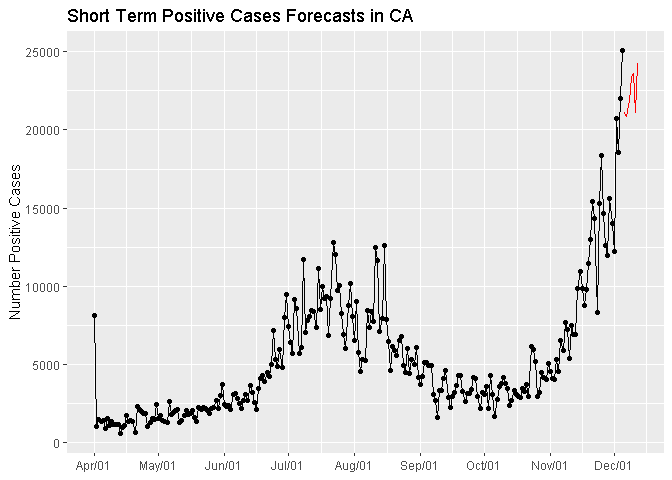

```r
#length of 242

dates <- seq(as.Date(COVID_totals_final_ca$date[ length(COVID_totals_final_ca$date) ]), by='day', length.out=8)[c(-1)]

forecasts <- data.frame(
  preds = new_pos_ca.fcast7$f,
  upper = new_pos_ca.fcast7$ul,
  lower = new_pos_ca.fcast7$ll,
  dates = dates
  )

#Visualize
ggplot(data=COVID_totals_final_ca, aes(x=date, y=new_pos)) +
  geom_line()+geom_point() + ggtitle('Short Term Positive Cases Forecasts in CA')+
  xlab(NULL)+ylab('Number Positive Cases')+
  scale_x_date(date_labels = "%b/%d", date_breaks = '1 month')+
  #scale_y_continuous(breaks=seq(0,3000, 300))+
  geom_line(data=forecasts, aes(x=dates, y=preds), color='red')
```

**ASE**

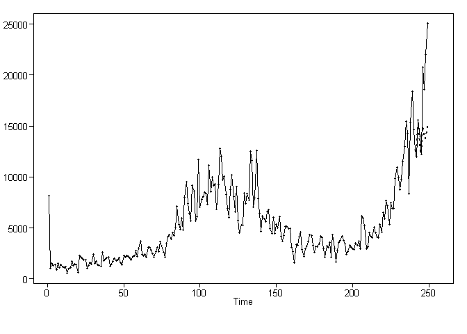

```r
#place holder for length
#NOTE since data is pulled live THIS WILL CHANGE
ase_length <- length(COVID_totals_final_ca$new_pos)

# short-term forecasts of n = 7
# using FULL data NOT training
fore.aruma.wge(COVID_totals_final_ca$new_pos,
               phi= new_pos_ca.est$phi,
               d=1,
               n.ahead=7,
               lastn = T,
               limits=F) -> new_pos_ca.ase7
```

```r
# Short-term ASE
mean(
  ( COVID_totals_final_ca$new_pos[(ase_length-6):ase_length ] - new_pos_ca.ase7$f )^2
  )
```

```
## [1] 31689924
```

**Rolling Window ASE**

```r
Rolling_Window_ASE(
  series = COVID_totals_final_ca$new_pos,
  trainingSize = 28,
  horizon = 7,
  phis = new_pos_ca.est$phi,
  d=1
  )
```

```
## [1] "The Summary Statistics for the Rolling Window ASE Are:"
##      Min.   1st Qu.    Median      Mean   3rd Qu.      Max.
##     65346    700514   4041062   9255794   9644145 103968164
## [1] "The Rolling Window ASE is:  9255793.79620519"
```

```
## [1] 9255794
```

**NOTE: UPDATED TO HOLDOUT OF 20**

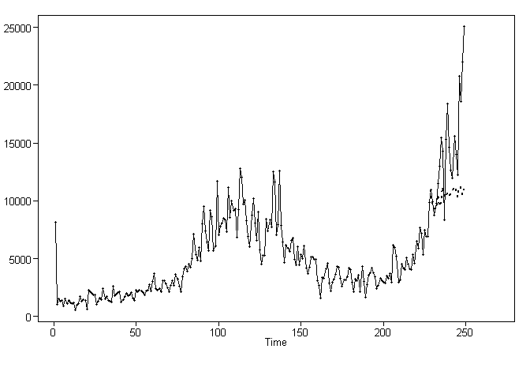

```r
#place holder for length
#NOTE since data is pulled live THIS WILL CHANGE
ase_length <- length(COVID_totals_final_ca$new_pos)

# ASE for n = 20
fore.aruma.wge(COVID_totals_final_ca$new_pos,
               phi= new_pos_ca.est$phi,
               d=1,
               n.ahead=20,
               lastn = T,
               limits=F) -> new_pos_ca.ase20
```

```r
# Short-term ASE
mean(
  ( COVID_totals_final_ca$new_pos[(ase_length-19):ase_length ] - new_pos_ca.ase20$f )^2
  )
```

```
## [1] 33622758
```

**Rolling Window ASE**

```r
Rolling_Window_ASE(
  series = COVID_totals_final_ca$new_pos,
  trainingSize = 50,
  horizon = 20,
  phis = new_pos_ca.est$phi,
  d=1
  )
```

```
## [1] "The Summary Statistics for the Rolling Window ASE Are:"
##      Min.   1st Qu.    Median      Mean   3rd Qu.      Max.
##    872032   4682059  11015393  16021032  18649853 124089893
## [1] "The Rolling Window ASE is:  16021032.3244023"
```

```
## [1] 16021032
```

### ARIMA: Long-Term Forecast

Forecasting out 90 days. As with $(1 - B)$2 AR it cycles back towards the last value

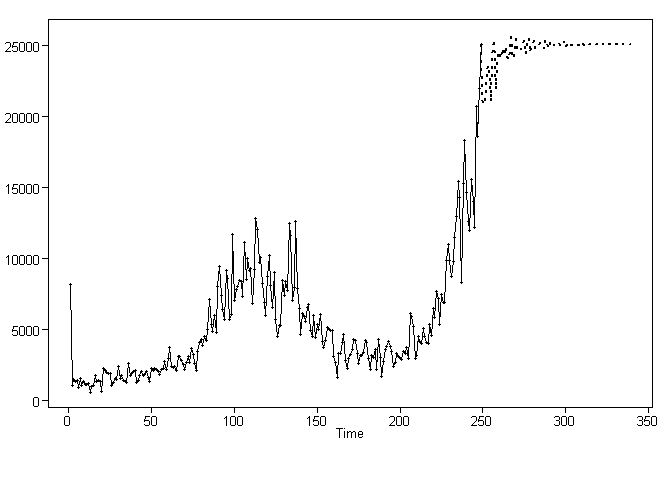

```r
# short-term forecasts of n = 90
# using FULL data NOT training
fore.aruma.wge(COVID_totals_final_ca$new_pos,
               phi=new_pos_ca.est$phi,
               d=1,
               n.ahead=90,
               limits=F) ->
  new_pos_ca.fcast90
```

**GGPLOT VISUALIZATION OF FORECASTS**

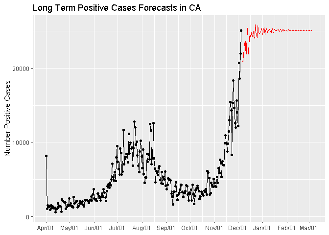

```r
#length of 242
#length(COVID_totals_final$date)

dates <- seq(as.Date(COVID_totals_final_ca$date[ length(COVID_totals_final_ca$date) ]), by='day', length.out=91)[c(-1)]

forecasts <- data.frame(
  preds = new_pos_ca.fcast90$f,
  upper = new_pos_ca.fcast90$ul,
  lower = new_pos_ca.fcast90$ll,
  dates = dates
  )

#Visualize
ggplot(data=COVID_totals_final_ca, aes(x=date, y=new_pos)) +
  geom_line()+geom_point() + ggtitle('Long Term Positive Cases Forecasts in CA')+
  xlab(NULL)+ylab('Number Positive Cases')+
  scale_x_date(date_labels = "%b/%d", date_breaks = '1 month')+
  #scale_y_continuous(breaks=seq(0,3000, 300))+
  geom_line(data=forecasts, aes(x=dates, y=preds), color='red')
```

## MLP Univariate Model

###Short-Term Model

```r
mlp_length <- length(COVID_totals_final_ca$new_pos)

# TRAIN / TEST SPLIT
# split for pred 7
COVID_totals_final_ca$new_pos[1:(mlp_length-7)] %>%
  as.ts() -> new_pos_ca.train


COVID_totals_final_ca$new_pos[(mlp_length-6):mlp_length] %>%
  as.ts() -> new_pos_ca.test
```

MLP MODEL STATS

```r
new_pos_ca.mlp <- mlp(
  new_pos_ca.ts,
  difforder = c(1),
  reps = 50,
  comb = "median")

new_pos_ca.mlp
```

```
## MLP fit with 5 hidden nodes and 50 repetitions.
## Series modelled in differences: D1.
## Univariate lags: (1,2,3)
## Forecast combined using the median operator.
## MSE: 1570708.4261.
```

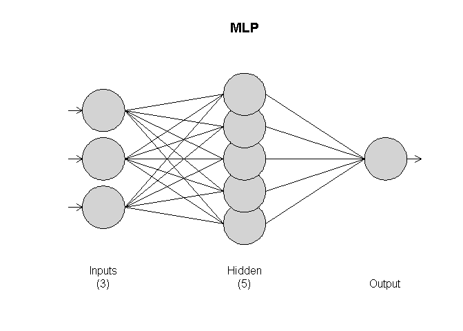

```r
# Visualize the Neural Network
plot(new_pos_ca.mlp)
```

**MLP Short-Term Predictions**

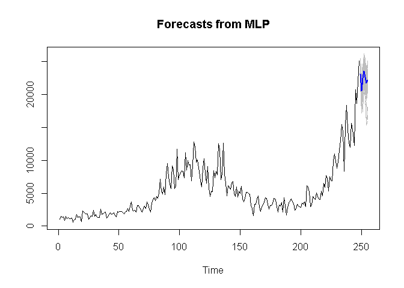

```r
#MLP Forecast
new_pos_ca.mlp.f7 <- forecast(new_pos_ca.mlp, h = 7 )
plot(new_pos_ca.mlp.f7)
```

BECAUSE THE GRAPH IS HARD TO READ WITH THE EXTREME OUTLIER

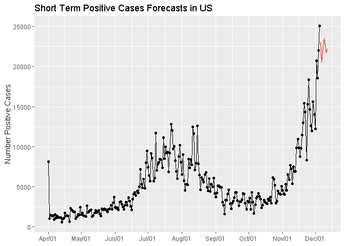

```r
dates <- seq(as.Date(COVID_totals_final_ca$date[ length(COVID_totals_final_ca$date) ]), by='day', length.out=8)[c(-1)]

forecasts <- data.frame(
  preds =  as.vector(new_pos_ca.mlp.f7$mean) ,
  dates = dates
  )

#Visualize
ggplot(data=COVID_totals_final_ca, aes(x=date, y=new_pos)) +
  geom_line()+geom_point() + ggtitle('Short Term Positive Cases Forecasts in US')+
  xlab(NULL)+ylab('Number Positive Cases')+
  scale_x_date(date_labels = "%b/%d", date_breaks = '1 month')+
  #scale_y_continuous(breaks=seq(0,3000, 300))+
  geom_line(data=forecasts, aes(x=dates, y=preds), color='red')
```

**MLP Short-Term ASE**

```r
#ASE MLP Model
new_pos_ca.ase.mlp <- mlp(
  new_pos_ca.train,
  difforder = c(1),
  reps = 50,
  comb = "median")
new_pos_ca.ase.mlp
```

```
## MLP fit with 5 hidden nodes and 50 repetitions.
## Series modelled in differences: D1.
## Univariate lags: (1,2,3)
## Forecast combined using the median operator.
## MSE: 1193658.257.
```

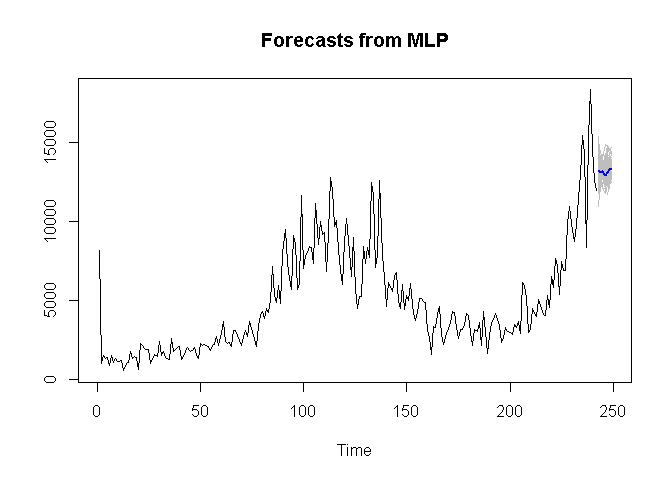

```r
new_pos_ca.mlp.ase.f <- forecast(new_pos_ca.ase.mlp, h = length(new_pos_ca.test) )

plot(new_pos_ca.mlp.ase.f)
```

```r
#ASE
mean(( as.vector(new_pos_ca.test) - as.vector(new_pos_ca.mlp.ase.f$mean) )^2)
```

```
## [1] 44617392
```

### Long-Term Model

```r
mlp_length <- length(COVID_totals_final_ca$new_pos)

# TRAIN / TEST SPLIT
# split for pred 30
COVID_totals_final_ca$new_pos[1:(mlp_length-90)] %>%
  as.ts() -> new_pos_ca.train


COVID_totals_final_ca$new_pos[(mlp_length-89):mlp_length] %>%
  as.ts() -> new_pos_ca.test
```

MLP MODEL STATS

```r
new_pos_ca.mlp <- mlp(
  new_pos_ca.ts,
  reps = 50,
  difforder = c(1),
  comb = "median")

new_pos_ca.mlp
```

```
## MLP fit with 5 hidden nodes and 50 repetitions.
## Series modelled in differences: D1.
## Univariate lags: (1,2,3)
## Forecast combined using the median operator.
## MSE: 1594971.7276.
```

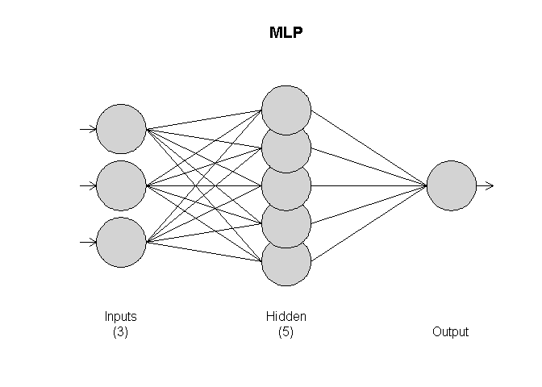

```r
# Visualize the Neural Network
plot(new_pos_ca.mlp)
```

**MLP Long-Term Predictions**

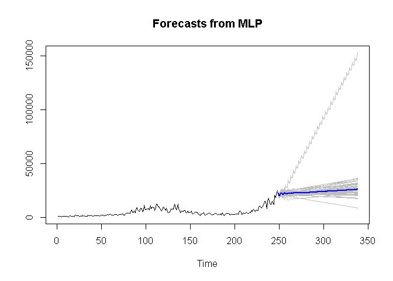

```r
#MLP Forecast
new_pos_ca.mlp.f90 <- forecast(new_pos_ca.mlp, h = 90 )
plot(new_pos_ca.mlp.f90)
```

BECAUSE THE GRAPH IS HARD TO READ WITH THE EXTREME OUTLIER

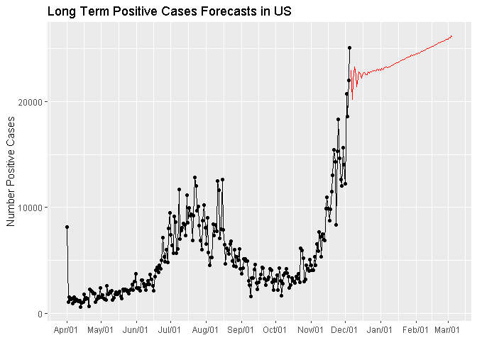

```r
dates <- seq(as.Date(COVID_totals_final_ca$date[ length(COVID_totals_final_ca$date) ]), by='day', length.out=91)[c(-1)]

forecasts <- data.frame(
  preds =  as.vector(new_pos_ca.mlp.f90$mean) ,
  dates = dates
  )

#Visualize
ggplot(data=COVID_totals_final_ca, aes(x=date, y=new_pos)) +
  geom_line()+geom_point() + ggtitle('Long Term Positive Cases Forecasts in US')+
  xlab(NULL)+ylab('Number Positive Cases')+
  scale_x_date(date_labels = "%b/%d", date_breaks = '1 month')+
  #scale_y_continuous(breaks=seq(0,3000, 300))+
  geom_line(data=forecasts, aes(x=dates, y=preds), color='red')
```

**MLP Long-Term ASE**

```r
#ASE MLP Model
new_pos_ca.ase.mlp <- mlp(
  new_pos_ca.train,
  reps = 50,
  comb = "mean")

new_pos_ca.ase.mlp
```

```
## MLP fit with 5 hidden nodes and 50 repetitions.
## Univariate lags: (1,3,4)
## Forecast combined using the mean operator.
## MSE: 1022595.9878.
```

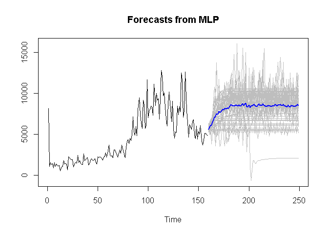

```r
new_pos_ca.mlp.ase.f <- forecast(new_pos_ca.ase.mlp, h = length(new_pos_ca.test) )

plot(new_pos_ca.mlp.ase.f)
```

```r
#ASE
mean(( as.vector(new_pos_ca.test) - as.vector(new_pos_ca.mlp.ase.f$mean) )^2)
```

```
## [1] 27668174
```

## Short-Term Univariate Ensemble

We average the predictions from the ARUMA and the MLP

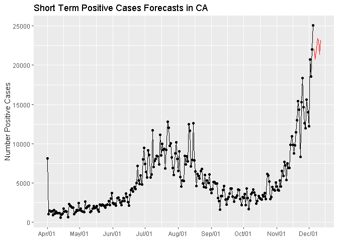

```r
dates <- seq(as.Date(COVID_totals_final_ca$date[ length(COVID_totals_final_ca$date) ]), by='day', length.out=8)[c(-1)]

forecasts <- data.frame(
  preds = (new_pos_ca.fcast7$f + as.vector(new_pos_ca.mlp.f7$mean))/2,
  dates = dates
  )

#Visualize
ggplot(data=COVID_totals_final_ca, aes(x=date, y=new_pos)) +
  geom_line()+geom_point() + ggtitle('Short Term Positive Cases Forecasts in CA')+
  xlab(NULL)+ylab('Number Positive Cases')+
  scale_x_date(date_labels = "%b/%d", date_breaks = '1 month')+
  #scale_y_continuous(breaks=seq(0,3000, 300))+
  geom_line(data=forecasts, aes(x=dates, y=preds), color='red')
```

```r
#ASE

mean(
  ((new_pos_ca.fcast7$f + as.vector(new_pos_ca.mlp.ase.f$mean))/2 - new_pos_ca.test)^2
)
```

```
## [1] 102829913
```

##Long-Term Univariate Ensemble

We average the predictions from the ARUMA and the MLP

[figure not shown]

```r
dates <- seq(as.Date(COVID_totals_final_ca$date[ length(COVID_totals_final_ca$date) ]), by='day', length.out=91)[c(-1)]

forecasts <- data.frame(
  preds = (new_pos_ca.fcast90$f + as.vector(new_pos_ca.mlp.f90$mean[[2]]))/2,
  dates = dates
  )

#Visualize
ggplot(data=COVID_totals_final_ca, aes(x=date, y=new_pos)) +
  geom_line()+geom_point() + ggtitle('Long Term Positive Cases Forecasts in CA')+
  xlab(NULL)+ylab('Number Positive Cases')+
  scale_x_date(date_labels = "%b/%d", date_breaks = '1 month')+
  scale_y_continuous(breaks=seq(0,3000, 300))+
  geom_line(data=forecasts, aes(x=dates, y=preds), color='red')
```

```r
#ASE

mean(
  ((new_pos_ca.fcast90$f + as.vector(new_pos_ca.mlp.ase.f$mean))/2 - new_pos_ca.test)^2
)
```

```
## [1] 125596173
```

## Multivariate Analysis: CA State - Daily Positives

Now we include other explanatory variables. * Particular days of the week, specifically weekdays vs weekends * Hospitalization

### CA: Weekday vs Weekend

```r
# populate "is_weekend" column
COVID_totals_final_ca$is_weekend <- 'Weekday'
# identify
COVID_totals_final_ca[COVID_totals_final_ca$day_of_week %in% c("Saturday","Sunday"), 'is_weekend'] <- 'Weekend'


COVID_totals_final_ca$is_weekend <- factor(
  COVID_totals_final_ca$is_weekend,
  levels=c('Weekday', 'Weekend')
  )

#confirm
COVID_totals_final_ca %>% dplyr::select(date, day_of_week, is_weekend) %>% tail(10)
```

```
##           date day_of_week is_weekend
## 464 2020-11-26    Thursday    Weekday
## 413 2020-11-27      Friday    Weekday
## 362 2020-11-28    Saturday    Weekend
## 311 2020-11-29      Sunday    Weekend
## 260 2020-11-30      Monday    Weekday
## 209 2020-12-01     Tuesday    Weekday
## 158 2020-12-02   Wednesday    Weekday
## 107 2020-12-03    Thursday    Weekday
## 56  2020-12-04      Friday    Weekday
## 5   2020-12-05    Saturday    Weekend
```

```r
###MLR using weekend
#holdout last 20 for ASE
#ggplot(COVID_US_final, aes(x=hospital_sum, y=new_pos)) + geom_point()
```

### Hospitalization - Lagged Correlation

Unfortunately we only find weakly moderate corelations

```r
cor.test( COVID_totals_final_ca$new_death , COVID_totals_final_ca$hospital_sum )
```

```
##
##  Pearson's product-moment correlation
##
## data:  COVID_totals_final_ca$new_death and COVID_totals_final_ca$hospital_sum
## t = 6.2531, df = 247, p-value = 1.757e-09
## alternative hypothesis: true correlation is not equal to 0
## 95 percent confidence interval:
##  0.2571945 0.4723006
## sample estimates:
##       cor
## 0.3696906
```

```r
cor.test( COVID_totals_final_ca$perc_death , COVID_totals_final_ca$hospital_sum )
```

```
##
##  Pearson's product-moment correlation
##
## data:  COVID_totals_final_ca$perc_death and COVID_totals_final_ca$hospital_sum
## t = -2.7339, df = 247, p-value = 0.006711
## alternative hypothesis: true correlation is not equal to 0
## 95 percent confidence interval:
##  -0.28953023 -0.04809083
## sample estimates:
##        cor
## -0.1713825
```

```r
# does hospitalization correlate to daily positives
# can it stop people from dying

ccf(COVID_totals_final_ca$new_pos, COVID_totals_final_ca$hospital_sum, lag.max = 14, type = "correlation", plot = F )
```

```
##
## Autocorrelations of series 'X', by lag
##
##   -14   -13   -12   -11   -10    -9    -8    -7    -6    -5    -4    -3
## 0.445 0.470 0.473 0.505 0.534 0.543 0.556 0.567 0.583 0.596 0.599 0.622
##    -2    -1     0     1     2     3     4     5     6     7     8     9
## 0.636 0.660 0.695 0.671 0.633 0.599 0.563 0.525 0.489 0.457 0.425 0.395
##    10    11    12    13    14
## 0.365 0.332 0.300 0.273 0.248
```

```r
ccf(COVID_totals_final_ca$new_death, COVID_totals_final_ca$hospital_sum, lag.max = 14, type = "correlation", plot = F )
```

```
##
## Autocorrelations of series 'X', by lag
##
##   -14   -13   -12   -11   -10    -9    -8    -7    -6    -5    -4    -3
## 0.035 0.051 0.052 0.069 0.087 0.101 0.132 0.167 0.185 0.185 0.200 0.220
##    -2    -1     0     1     2     3     4     5     6     7     8     9
## 0.245 0.298 0.370 0.405 0.413 0.413 0.404 0.408 0.424 0.444 0.454 0.446
##    10    11    12    13    14
## 0.437 0.432 0.428 0.435 0.454
```

```r
ccf(COVID_totals_final_ca$perc_death, COVID_totals_final_ca$hospital_sum, lag.max = 14, type = "correlation", plot = F )
```

```
##
## Autocorrelations of series 'X', by lag
##
##    -14    -13    -12    -11    -10     -9     -8     -7     -6     -5
## -0.057 -0.049 -0.050 -0.055 -0.058 -0.043 -0.061 -0.086 -0.057 -0.065
##     -4     -3     -2     -1      0      1      2      3      4      5
## -0.089 -0.118 -0.092 -0.085 -0.171 -0.116 -0.101 -0.145 -0.170 -0.149
##      6      7      8      9     10     11     12     13     14
## -0.109 -0.123 -0.133 -0.132 -0.099 -0.103 -0.102 -0.016 -0.013
```

### VAR: CA - State

Looking for lagged correlation between hospitalized patients in order to help understand if hospitalization is effectively identifying or controlling COVID outbreaks

```r
new_pos_ca.mtx <- cbind( COVID_totals_final_ca$new_pos, COVID_totals_final_ca$hospital_sum  )

# picks p of 9
VARselect(new_pos_ca.mtx, lag.max = 12, type = "both" )$selection
```

```
## AIC(n)  HQ(n)  SC(n) FPE(n)
##      9      9      4      9
```

####Short Term VAR Forecast

```r
# VAR model
VAR(new_pos_ca.mtx, p=9, type = "both") -> new_pos_ca.var
# predictions
predict(new_pos_ca.var, n.ahead = 7 ) -> new_pos_ca.var.pred7
```

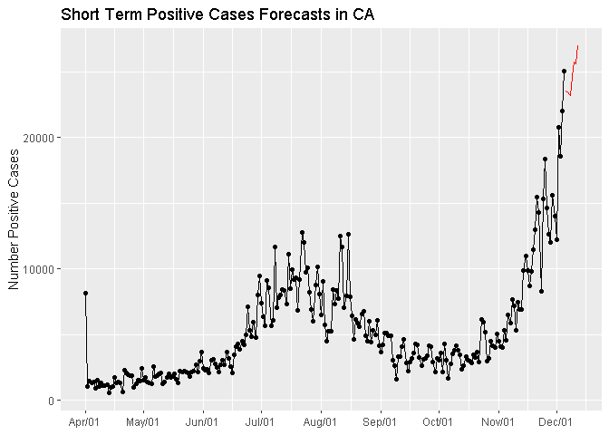

```r
dates <- seq(as.Date(COVID_totals_final_ca$date[ length(COVID_totals_final_ca$date) ]), by='day', length.out=8)[c(-1)]

forecasts <- data.frame(
  preds = new_pos_ca.var.pred7$fcst$y1[,1],
  upper = new_pos_ca.var.pred7$fcst$y1[,3],
  lower = new_pos_ca.var.pred7$fcst$y1[,2],
  dates = dates
  )

#Visualize
ggplot(data=COVID_totals_final_ca, aes(x=date, y=new_pos)) +
  geom_line()+geom_point() + ggtitle('Short Term Positive Cases Forecasts in CA')+
  xlab(NULL)+ylab('Number Positive Cases')+
  scale_x_date(date_labels = "%b/%d", date_breaks = '1 month')+
  #scale_y_continuous(breaks=seq(0,3000, 300))+
  geom_line(data=forecasts, aes(x=dates, y=preds), color='red')
```

####Long Term VAR Forecast

```r
# VAR model
VAR(new_pos_ca.mtx, p=9, type = "both") -> new_pos_ca.var
# predictions
predict(new_pos_ca.var, n.ahead = 90 ) -> new_pos_ca.var.pred90
```

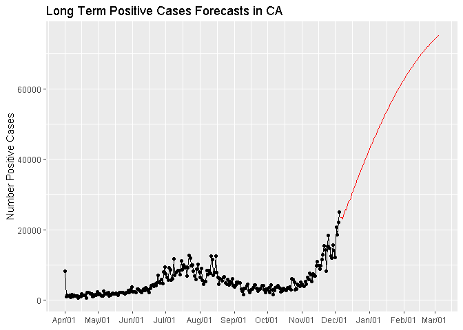

```r
dates <- seq(as.Date(COVID_totals_final_ca$date[ length(COVID_totals_final_ca$date) ]), by='day', length.out=91)[c(-1)]

forecasts <- data.frame(
  preds = new_pos_ca.var.pred90$fcst$y1[,1],
  upper = new_pos_ca.var.pred90$fcst$y1[,3],
  lower = new_pos_ca.var.pred90$fcst$y1[,2],
  dates = dates
  )

#Visualize
ggplot(data=COVID_totals_final_ca, aes(x=date, y=new_pos)) +
  geom_line()+geom_point() + ggtitle('Long Term Positive Cases Forecasts in CA')+
  xlab(NULL)+ylab('Number Positive Cases')+
  scale_x_date(date_labels = "%b/%d", date_breaks = '1 month')+
  #scale_y_continuous(breaks=seq(0,3000, 300))+
  geom_line(data=forecasts, aes(x=dates, y=preds), color='red')
```

### MLP Model: Multivariate - CA State

####Model Evaluation

NOTE: hospital was detracting from model efficacy. Decided to remove it

```r
mlp_length <- length(COVID_totals_final_ca$new_pos)

# TRAIN / TEST SPLIT
# hold out 20
COVID_totals_final_ca$new_pos[1:(mlp_length-20)] %>%
  as.ts() -> new_pos_ca.train


COVID_totals_final_ca$new_pos[(mlp_length-19):mlp_length] %>%
  as.ts() -> new_pos_ca.test

## EXPLANATORY DATAFRAME

xreg_ca.df = data.frame(
  #hospital_sum = ts(COVID_totals_final_ca$hospital_sum),
  is_weekend = ts(COVID_totals_final_ca$is_weekend),
  t = as.ts(COVID_totals_final_ca$date - min(COVID_totals_final_ca$date) + 1 )
  )

head(xreg_ca.df)
```

```
##   is_weekend t
## 1          1 1
## 2          1 2
## 3          1 3
## 4          2 4
## 5          2 5
## 6          1 6
```

MLP MODEL STATS

NOTE: Prior univariate MSE: 47144729.4646

```r
new_pos_ca.mul.mlp <- mlp(
  new_pos_ca.train,
  xreg = xreg_ca.df,
  difforder = c(1),
  #allow.det.season = F,
  reps = 50,
  comb = "mean")

new_pos_ca.mul.mlp
```

```
## MLP fit with 5 hidden nodes and 50 repetitions.
## Series modelled in differences: D1.
## Univariate lags: (1,2,3)
## 1 regressor included.
## - Regressor 1 lags: (2,3,4)
## Forecast combined using the mean operator.
## MSE: 551558.5197.
```

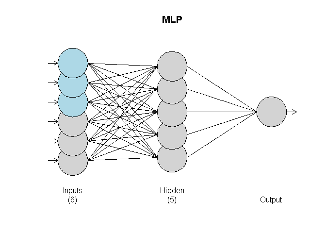

```r
# Visualize the Neural Network
plot(new_pos_ca.mul.mlp)
```

We forecast out the 20 hold out values and visually examine them. First in context of the entire realization…

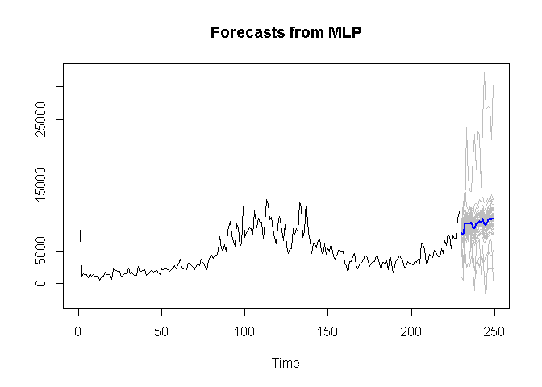

```r
#MLP Forecast
new_pos_ca.mul.mlp.f <- forecast(
  new_pos_ca.mul.mlp,
  h = 20,
  xreg = xreg_ca.df
  )

plot(new_pos_ca.mul.mlp.f)
```

Then focusing on comparing the last 20 with both the actual in black vs the projected in red.

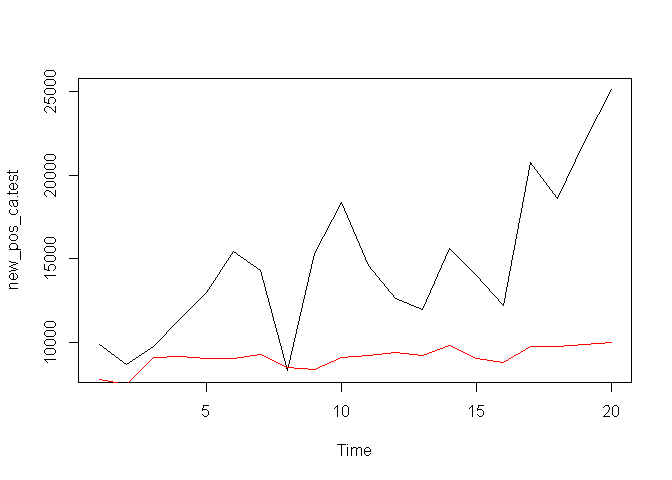

```r
plot(new_pos_ca.test,type = "l")
lines(seq(1,20),new_pos_ca.mul.mlp.f$mean, col = "red")
```

```r
#ASE
mean(( new_pos_ca.test - as.numeric(new_pos_ca.mul.mlp.f$mean) )^2)
```

```
## [1] 45539302
```

####Short-Term Multivariate MLP Forecast

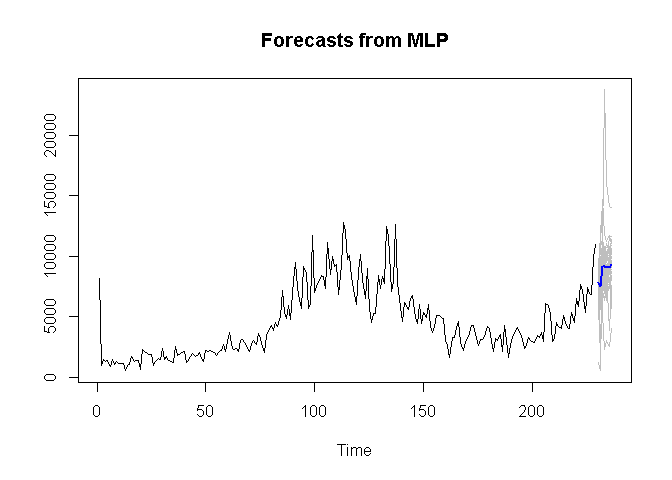

```r
#next 7 is_weekends
last_day = COVID_totals_final_ca$date[ length(COVID_totals_final_ca$date) ]
next7dates = seq(last_day, by = "day", length.out = 8)[-1]
next7weekdays = weekdays(next7dates)
next7_isweekend = ifelse(next7weekdays %in% c("Saturday","Sunday"), 'Weekend', 'Weekday')
next7_isweekend = as.factor(next7_isweekend)

#next 7 days
mlp_length <- length(COVID_totals_final_ca$new_pos)
(mlp_length+1):(mlp_length+7) -> next7time

#t parameter
t <- as.numeric(COVID_totals_final_ca$date - min(COVID_totals_final_ca$date) + 1 )

#combine 7 day forecasts with previous dependent vars
xreg_ca7 <- data.frame(
  is_weekend = ts(c(COVID_totals_final_ca$is_weekend, next7_isweekend)),
  time = ts(c( t , next7time))
  )

#forecast the next 7 total positive datapoints using the
#forecasted time and is_weekend as predictors
new_pos_ca.mlp.next7 <- forecast(new_pos_ca.mul.mlp, h = 7, xreg = xreg_ca7)
plot(new_pos_ca.mlp.next7)
```

####Long-Term Multivariate MLP Forecast

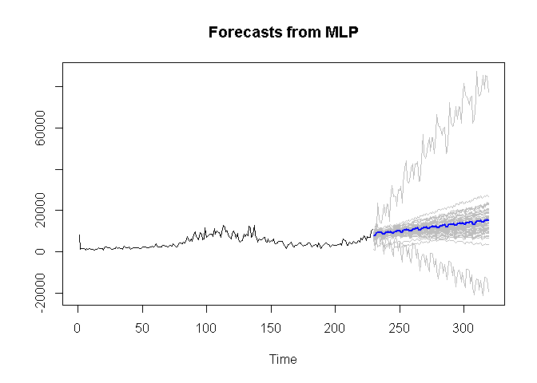

```r
#next 7 is_weekends
last_day = COVID_totals_final_ca$date[ length(COVID_totals_final_ca$date) ]
next90dates = seq(last_day, by = "day", length.out = 91)[-1]
next90weekdays = weekdays(next90dates)
next90_isweekend = ifelse(next90weekdays %in% c("Saturday","Sunday"), 'Weekend', 'Weekday')
next90_isweekend = as.factor(next90_isweekend)

#next 7 days
mlp_length <- length(COVID_totals_final_ca$new_pos)
(mlp_length+1):(mlp_length+90) -> next90time

#t parameter
t <- as.numeric(COVID_totals_final_ca$date - min(COVID_totals_final_ca$date) + 1 )

#combine 90 day forecasts with previous dependent vars
xreg_ca90 <- data.frame(
  is_weekend = ts(c(COVID_totals_final_ca$is_weekend, next90_isweekend)),
  time = ts(c( t , next90time))
  )

#forecast the next 7 total positive datapoints using the
#forecasted time and is_weekend as predictors
new_pos_ca.mlp.next90 <- forecast(new_pos_ca.mul.mlp, h = 90, xreg = xreg_ca90)
plot(new_pos_ca.mlp.next90)
```

##Short-Term Multivariate Ensemble

We average the predictions from the ARIMA Univariate, Univariate and Multivariate MLP, and VAR Multivariate

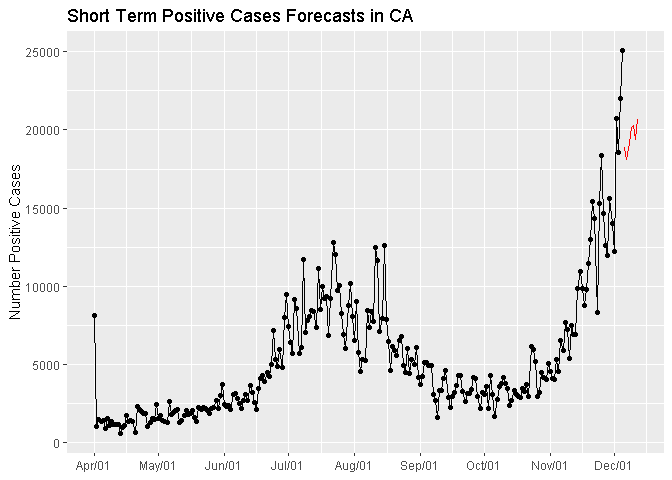

```r
dates <- seq(as.Date(COVID_totals_final_ca$date[ length(COVID_totals_final_ca$date) ]), by='day', length.out=8)[c(-1)]

forecasts <- data.frame(
  preds = (new_pos_ca.fcast7$f + as.vector(new_pos_ca.mlp.f7$mean) + as.vector(new_pos_ca.mlp.next7[[2]]) + new_pos_ca.var.pred7$fcst$y1[,1] )/4,
  dates = dates
  )

#Visualize
ggplot(data=COVID_totals_final_ca, aes(x=date, y=new_pos)) +
  geom_line()+geom_point() + ggtitle('Short Term Positive Cases Forecasts in CA')+
  xlab(NULL)+ylab('Number Positive Cases')+
  scale_x_date(date_labels = "%b/%d", date_breaks = '1 month')+
  #scale_y_continuous(breaks=seq(0,3000, 300))+
  geom_line(data=forecasts, aes(x=dates, y=preds), color='red')
```

Comparing predictions of different models

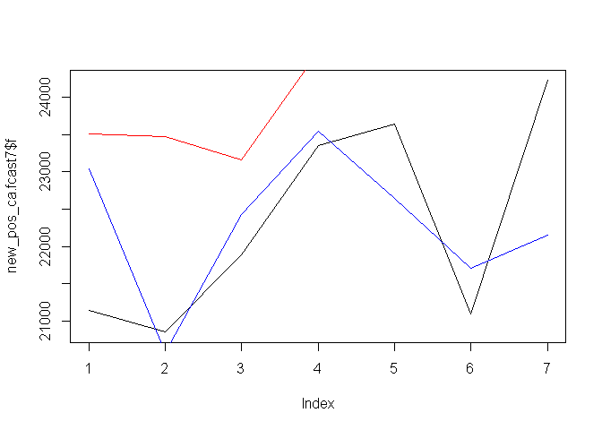

```r
# ARIMA Univariate
plot(new_pos_ca.fcast7$f,type = "l")
# VAR Multivariate
lines(seq(1,7), as.vector(new_pos_ca.var.pred7$fcst$y1[,1]) , col = "red")
# MLP Univariate
lines(seq(1,7), as.vector(new_pos_ca.mlp.f7$mean) , col = "blue")
# MLP Multivariate
lines(seq(1,7), as.vector(new_pos_ca.mlp.next7[[2]]) , col = "green")
```

##Long-Term Multivariate Ensemble

We average the predictions from the ARIMA Univariate, Univariate and Multivariate MLP, and VAR Multivariate

**RED** * ARIMA Univariate * VAR Multivariate * MLP Univariate * MLP Multivariate

[figure not shown]

```r
dates <- seq(as.Date(COVID_totals_final_ca$date[ length(COVID_totals_final_ca$date) ]), by='day', length.out=91)[c(-1)]


new_pos_ca.fcast90$f -> new_pos.arima.p90
as.vector(new_pos_ca.mlp.next90[[2]]) -> new_pos.mlp_multi.p90
as.vector(new_pos_ca.mlp.f90$mean) -> new_pos.mlp_uni.p90
as.vector(new_pos_ca.var.pred90$fcst$y1[,1]) -> new_pos.var.p90

forecasts <- data.frame(
  preds = (new_pos.arima.p90 + new_pos.mlp_uni.p90 + as.vector(new_pos_ca.mlp.next90[[2]]) + new_pos.var.p90 )/4,
  predsopt = ( new_pos.mlp_uni.p90 + new_pos.var.p90 + new_pos.arima.p90 )/3,
  predsdual = ( new_pos.mlp_uni.p90 + new_pos.arima.p90 )/2,
  dates = dates
  )

#Visualize
ggplot(data=COVID_totals_final_ca, aes(x=date, y=new_pos)) +
  geom_line()+geom_point() + ggtitle('Short Term Positive Cases Forecasts in CA')+
  xlab(NULL)+ylab('Number Positive Cases')+
  scale_x_date(date_labels = "%b/%d", date_breaks = '1 month')+
  scale_y_continuous(breaks=seq(0,3000, 300))+
  geom_line(data=forecasts, aes(x=dates, y=preds), color='red')+
  geom_line(data=forecasts, aes(x=dates, y=predsopt), color='blue')+
  geom_line(data=forecasts, aes(x=dates, y=predsdual), color='green')
```

Comparing predictions of different models

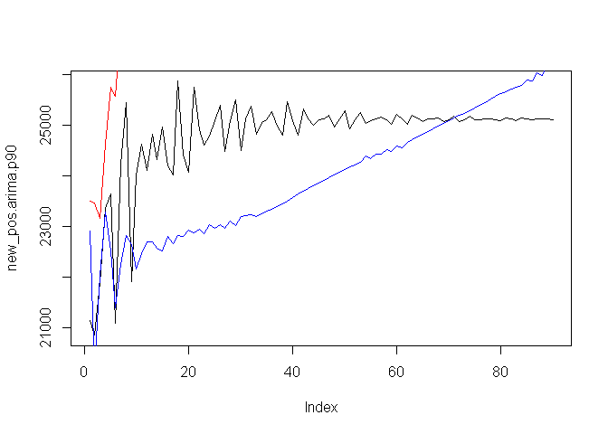

```r
# ARIMA Univariate
plot( new_pos.arima.p90 ,type = "l")
# VAR Multivariate
lines(seq(1,90), new_pos.var.p90 , col = "red")
# MLP Univariate
lines(seq(1,90), new_pos.mlp_uni.p90 , col = "blue")
# MLP Multivariate
lines(seq(1,90), new_pos.mlp_multi.p90 , col = "green")
```

# CA National Death

```r
#ccf(COVID_totals_final_ca$hospital_sum, COVID_totals_final_ca$new_death)
#ccf(COVID_totals_final_ca$, COVID_totals_final_ca$new_death)

n = length(COVID_totals_final_ca$new_death)


#VAR ASE

VARselect(
  cbind(
    COVID_totals_final_ca$new_death,
    COVID_totals_final_ca$hospital_sum),
  lag.max = 10,
  type='both')$selection
```

```
## AIC(n)  HQ(n)  SC(n) FPE(n)
##      7      7      7      7
```

```r
#picks VAR7
```

```r
new_death.var <- VAR(
  COVID_totals_final_ca[,c('new_death','hospital_sum')],
  p=7,
  type='both')

new_death.var.ase <- predict(new_death.var,n.ahead=20)
```

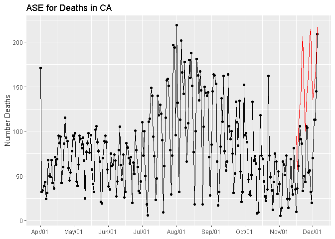

```r
dates = seq(as.Date(COVID_totals_final_ca$date[(n-20+1)]), by='day', length.out=20)

forecasts = data.frame(preds = new_death.var.ase$fcst$new_death[,1],date=dates)
ggplot(data=COVID_totals_final_ca, aes(x=date, y=new_death)) +
  geom_line()+geom_point() + ggtitle('ASE for Deaths in CA')+
  xlab(NULL)+ylab('Number Deaths')+
  scale_x_date(date_labels = "%b/%d", date_breaks = '1 month')+
  #scale_y_continuous(labels = scales::comma)+
  geom_line(data=forecasts, aes(x=dates, y=preds), color='red')
```

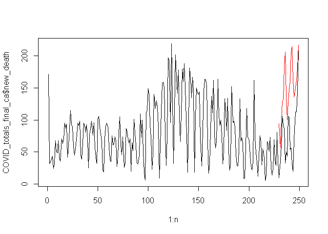

```r
plot(1:n, COVID_totals_final_ca$new_death, type='l')
lines((n-20+1):n, new_death.var.ase$fcst$new_death[,1], type='l', col='red')
```

```r
#ASE
mean((COVID_totals_final_ca$new_death[(n-20+1):n] - new_death.var.ase$fcst$new_death[,1] )^2)
```

```
## [1] 8058.034
```

```r
#488.0522
```

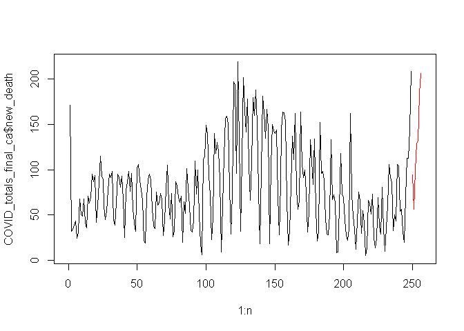

```r
#Predict 7 ahead

new_death.var.f7 <- predict(new_death.var, n.ahead=7)
plot(1:n, COVID_totals_final_ca$new_death, type='l', xlim=c(0,n+8))
lines((n+1):(n+7), new_death.var.f7$fcst$new_death[,1], type='l', col='red')
```

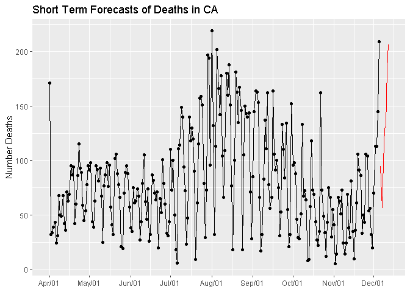

```r
dates = seq(as.Date(COVID_totals_final_ca$date[n]), by='day', length.out=8)[c(-1)]
forecasts = data.frame(
  preds = new_death.var.f7$fcst$new_death[,1],
  date=dates
  )

#Visualize
ggplot(data=COVID_totals_final_ca, aes(x=date, y=new_death)) +
  geom_line()+geom_point() + ggtitle('Short Term Forecasts of Deaths in CA')+
  xlab(NULL)+ylab('Number Deaths')+
  scale_x_date(date_labels = "%b/%d", date_breaks = '1 month')+
  geom_line(data=forecasts, aes(x=dates, y=preds), color='red')
```

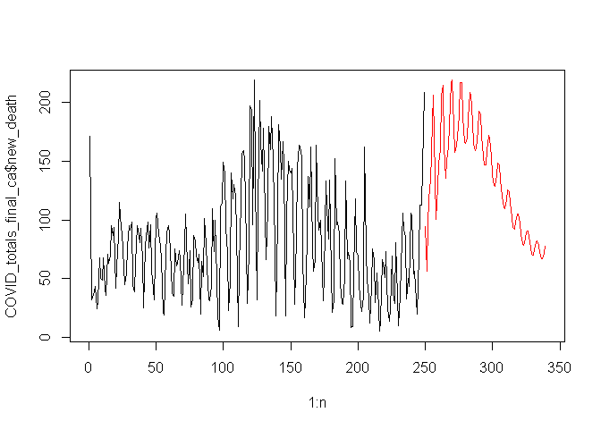

```r
#Predict 93 ahead

new_death.var.f90 =predict(new_death.var,n.ahead=90)
plot(1:n, COVID_totals_final_ca$new_death, type='l', xlim=c(0,n+91))
lines((n+1):(n+90), new_death.var.f90$fcst$new_death[,1], type='l', col='red')
```

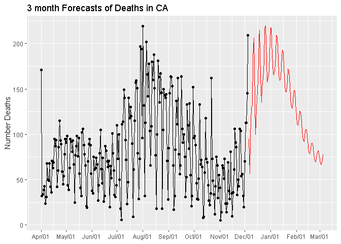

```r
n = length(COVID_totals_final_ca$new_death)
dates = seq(as.Date(COVID_totals_final_ca$date[n]), by='day', length.out=91)[c(-1)]
forecasts = data.frame(preds = new_death.var.f90$fcst$new_death[,1],
                       date=dates)
#Visualize
ggplot(data=COVID_totals_final_ca, aes(x=date, y=new_death)) +
  geom_line()+geom_point() + ggtitle('3 month Forecasts of Deaths in CA')+
  xlab(NULL)+ylab('Number Deaths')+
  scale_x_date(date_labels = "%b/%d", date_breaks = '1 month')+
  geom_line(data=forecasts, aes(x=dates, y=preds), color='red')
```

```r
summary(new_death.var)
```

```
##
## VAR Estimation Results:
## =========================
## Endogenous variables: new_death, hospital_sum
## Deterministic variables: both
## Sample size: 242
## Log Likelihood: -2788.622
## Roots of the characteristic polynomial:
## 0.9921 0.9921 0.9765 0.9765 0.9372 0.9372 0.7785 0.7785 0.7635 0.7292 0.7292 0.7155 0.7155 0.3617
## Call:
## VAR(y = COVID_totals_final_ca[, c("new_death", "hospital_sum")],
##     p = 7, type = "both")
##
##
## Estimation results for equation new_death:
## ==========================================
## new_death = new_death.l1 + hospital_sum.l1 + new_death.l2 + hospital_sum.l2 + new_death.l3 + hospital_sum.l3 + new_death.l4 + hospital_sum.l4 + new_death.l5 + hospital_sum.l5 + new_death.l6 + hospital_sum.l6 + new_death.l7 + hospital_sum.l7 + const + trend
##
##                  Estimate Std. Error t value Pr(>|t|)
## new_death.l1     0.252274   0.058640   4.302 2.52e-05 ***
## hospital_sum.l1 -0.002600   0.007053  -0.369 0.712769
## new_death.l2    -0.140272   0.058533  -2.396 0.017369 *
## hospital_sum.l2  0.005371   0.008561   0.627 0.531037
## new_death.l3    -0.025850   0.059347  -0.436 0.663563
## hospital_sum.l3  0.004392   0.008554   0.513 0.608138
## new_death.l4     0.001188   0.059386   0.020 0.984056
## hospital_sum.l4 -0.010541   0.009359  -1.126 0.261217
## new_death.l5    -0.215586   0.059017  -3.653 0.000322 ***
## hospital_sum.l5  0.004507   0.008590   0.525 0.600289
## new_death.l6     0.251118   0.059471   4.223 3.50e-05 ***
## hospital_sum.l6 -0.005276   0.008590  -0.614 0.539673
## new_death.l7     0.446027   0.056778   7.856 1.60e-13 ***
## hospital_sum.l7  0.011656   0.007327   1.591 0.113063
## const           -3.384037   7.203747  -0.470 0.638979
## trend            0.010607   0.024381   0.435 0.663934
## ---
## Signif. codes:  0 '***' 0.001 '**' 0.01 '*' 0.05 '.' 0.1 ' ' 1
##
##
## Residual standard error: 25.98 on 226 degrees of freedom
```

[output cut: 29 more lines]

```
## Residual standard error: 243.8 on 226 degrees of freedom
## Multiple R-Squared: 0.9825,  Adjusted R-squared: 0.9813
## F-statistic: 845.4 on 15 and 226 DF,  p-value: < 2.2e-16
##
##
##
## Covariance matrix of residuals:
##              new_death hospital_sum
## new_death       675.09       -61.36
## hospital_sum    -61.36     59441.90
##
## Correlation matrix of residuals:
##              new_death hospital_sum
## new_death     1.000000    -0.009686
## hospital_sum -0.009686     1.000000
```

```r
#Rolling window ASE
#took the average of five 10 data point windows

n = length(COVID_totals_final_ca$new_death)
aseholder = rep(0,5)
preds_dates = data.frame(dates1=seq(as.Date("2014/09/04"), by = "day", length.out = 10),
                         dates2 = seq(as.Date("2014/09/04"), by = "day", length.out = 10),
                         dates3=seq(as.Date("2014/09/04"), by = "day", length.out = 10),
                         dates4=seq(as.Date("2014/09/04"), by = "day", length.out = 10),
                         dates5 = seq(as.Date("2014/09/04"), by = "day", length.out = 10))

preds_list = data.frame(preds1=rep(0,10),preds2 = rep(0,10),
                        preds3=rep(0,10), preds4=rep(0,10),
                        preds5 = rep(0,10))

start = 1
end = start+60
for(i in 1:5){
  train_ind = start:end
  horizon_ind = (end+1):(end+10)
  preds_dates[,i] = COVID_totals_final_ca$date[horizon_ind]
  actual = COVID_totals_final_ca$new_death[horizon_ind]
  end = end+20


  #get predictions
  VAR_comb = VAR(COVID_totals_final_ca[train_ind,c('new_death','hospital_sum')],
                 p=7, type='both')

  preds.var.ASE=predict(VAR_comb,n.ahead=10)
  predicted = preds.var.ASE$fcst$new_death[,1]
  preds_list[,i] = predicted
  ASE = mean((actual - predicted)**2)

  #add ASE to aseholder
  aseholder[i] = ASE

}

print(mean(aseholder))
```

```
## [1] 1448.598
```

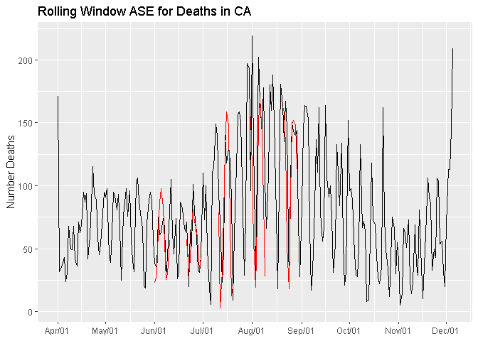

```r
forecasts = cbind(preds_list, preds_dates)

ggplot(COVID_totals_final_ca, aes(x=date, y=new_death)) +
  geom_line() +
  geom_line(data=forecasts, aes(x=dates1, y=preds1), color='red')+
  geom_line(data=forecasts, aes(x=dates2, y=preds2), color='red')+
  geom_line(data=forecasts, aes(x=dates3, y=preds3), color='red')+
  geom_line(data=forecasts, aes(x=dates4, y=preds4), color='red')+
  geom_line(data=forecasts, aes(x=dates5, y=preds5), color='red')+
  ggtitle('Rolling Window ASE for Deaths in CA')+
  xlab(NULL)+ylab('Number Deaths')+
  scale_x_date(date_labels = "%b/%d", date_breaks = '1 month')
```

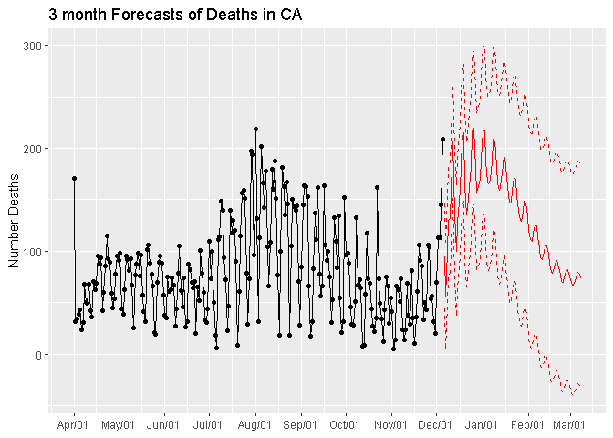

```r
##confidence interval


#Predict 93 ahead
preds.var.93 =predict(new_death.var,n.ahead=93)

n = length(COVID_totals_final_ca$new_death)
dates = seq(as.Date(COVID_totals_final_ca$date[n]), by='day', length.out=94)[c(-1)]
forecasts = data.frame(preds = preds.var.93$fcst$new_death[,1],
                       date=dates, upper = preds.var.93$fcst$new_death[,'upper'],
                       lower = preds.var.93$fcst$new_death[,'lower'])
#Visualize
ggplot(data=COVID_totals_final_ca, aes(x=date, y=new_death)) +
  geom_line()+geom_point() + ggtitle('3 month Forecasts of Deaths in CA')+
  xlab(NULL)+ylab('Number Deaths')+
  scale_x_date(date_labels = "%b/%d", date_breaks = '1 month')+
  geom_line(data=forecasts, aes(x=dates, y=preds), color='red')+
  geom_line(data=forecasts, aes(x=dates, y=upper), color='red',
            linetype = "dashed")+
  geom_line(data=forecasts, aes(x=dates, y=lower), color='red',
            linetype = "dashed")
```